# CPLN505-Assignment 3

Yihong Hu & Anna Duan

4/22/2022

# 1 Part 1: Modelling Land Use Change

In this report, we will develop a binary model to predict the possibility of land-use change in Chester County, PA. We want to know: (1) What are the main factors that determine a location to change from non-urban to urban in Chester County. (2) What are the possibility for specific locations for land-use change in Chester County

```r
# Read Chester land use Data and its geometry
Chester_L <- read.csv("Chester_Urban_Growth.csv")
Chester_L_geo <-
  Chester_L%>%
  st_as_sf(coords=c("X","Y"),crs = "EPSG:25832")
```

## 1.1 Summary Statistics

|  | SLOPE | DIST_WATER | DIST_RAILS | DIST_REGRA | DIST_PASSR | DIST_4LNE_ | DIST_INTER | DIST_PARKS | POPDEN90 | MEDINC90 | MEDHSEVAL_ | PCT_WHITE_ | PCT_SFHOME | PCT_POV_90 | PCT_HSB_19 | PCT_COLGRD |
| --- | --- | --- | --- | --- | --- | --- | --- | --- | --- | --- | --- | --- | --- | --- | --- | --- |
|  | Min. : 0.050 | Min. : 0 | Min. : 0 | Min. : 0 | Min. : 0 | Min. : 0 | Min. : 0 | Min. : 0 | Min. : 0 | Min. : 0 | Min. : 0 | Min. : 34.00 | Min. : 0.00 | Min. : 0.000 | Min. : 0.00 | Min. : 0.000 |
|  | 1st Qu.: 1.344 | 1st Qu.: 1414 | 1st Qu.: 6671 | 1st Qu.: 6265 | 1st Qu.: 1000 | 1st Qu.: 1414 | 1st Qu.: 5590 | 1st Qu.: 2500 | 1st Qu.: 21 | 1st Qu.: 37986 | 1st Qu.:128000 | 1st Qu.: 94.00 | 1st Qu.: 77.00 | 1st Qu.: 2.000 | 1st Qu.: 14.00 | 1st Qu.: 2.000 |
|  | Median : 2.048 | Median : 3162 | Median :12500 | Median :12176 | Median : 2236 | Median : 3000 | Median :12530 | Median : 4472 | Median : 61 | Median : 45074 | Median :150200 | Median : 97.00 | Median : 86.00 | Median : 4.000 | Median : 19.00 | Median : 4.000 |
|  | Mean : 2.407 | Mean : 3753 | Mean :13233 | Mean :12918 | Mean : 2763 | Mean : 3416 | Mean :15640 | Mean : 5161 | Mean : 189 | Mean : 48876 | Mean :167526 | Mean : 94.74 | Mean : 82.67 | Mean : 4.424 | Mean : 23.11 | Mean : 4.424 |
|  | 3rd Qu.: 3.036 | 3rd Qu.: 5701 | 3rd Qu.:18201 | 3rd Qu.:18000 | 3rd Qu.: 4123 | 3rd Qu.: 5315 | 3rd Qu.:24076 | 3rd Qu.: 7106 | 3rd Qu.: 154 | 3rd Qu.: 56394 | 3rd Qu.:214200 | 3rd Qu.: 98.00 | 3rd Qu.: 93.00 | 3rd Qu.: 6.000 | 3rd Qu.: 31.00 | 3rd Qu.: 6.000 |
|  | Max. :12.042 | Max. :13730 | Max. :40771 | Max. :40771 | Max. :11181 | Max. :11511 | Max. :49359 | Max. :16808 | Max. :13000 | Max. :103043 | Max. :384000 | Max. :100.00 | Max. :100.00 | Max. :29.000 | Max. :100.00 | Max. :29.000 |

## 1.2 Binary Variables

```r
#Find urban land use change between 1992 and 2001
Chester_L <-
  Chester_L %>%
  mutate(CHNG_URB = URBAN01 - URBAN92)

#Negative indicates that the urban land use  in 1992 has changed to other use in 2021. Replace them with 0.
Chester_L$CHNG_URB[Chester_L$CHNG_URB < 0] <- 0
```

## 1.3 Build Binomial Logit Model

First, we cleaned the dataset. We changed the some zeros to “NA”, so the regression can bypass them.

```r
Chester_L_clean <- Chester_L %>%
  select(DIST_WATER,DIST_RAILS, DIST_REGRA, DIST_PASSR, DIST_4LNE_, DIST_INTER, DIST_PARKS)

is.na(Chester_L_clean) <- !Chester_L_clean

Chester_Clean_2 <- Chester_L %>%
  select(-DIST_WATER,-DIST_RAILS, -DIST_REGRA, -DIST_PASSR, -DIST_4LNE_, -DIST_INTER, -DIST_PARKS)

Chester_L_Final <-
  cbind(Chester_L_clean, Chester_Clean_2)

bi_model <-
  glm(CHNG_URB ~ FOURLNE300 + INTERST800 + REGRAIL300 + RAILSTN100 + PARKS500M + WATER100 + CITBORO_10 + POPDEN90 + MEDINC90 + MEDHSEVAL_ + PCT_WHITE_ + PCT_SFHOME + PCT_POV_90 + PCT_HSB_19 + PCT_COLGRD + DIST_WATER + DIST_RAILS + DIST_REGRA + DIST_PASSR + DIST_4LNE_ + DIST_INTER+ DIST_PARKS, family = binomial, data = Chester_L_Final)

summary(bi_model)
```

```
##
## Call:
## glm(formula = CHNG_URB ~ FOURLNE300 + INTERST800 + REGRAIL300 +
##     RAILSTN100 + PARKS500M + WATER100 + CITBORO_10 + POPDEN90 +
##     MEDINC90 + MEDHSEVAL_ + PCT_WHITE_ + PCT_SFHOME + PCT_POV_90 +
##     PCT_HSB_19 + PCT_COLGRD + DIST_WATER + DIST_RAILS + DIST_REGRA +
##     DIST_PASSR + DIST_4LNE_ + DIST_INTER + DIST_PARKS, family = binomial,
##     data = Chester_L_Final)
##
## Deviance Residuals:
##     Min       1Q   Median       3Q      Max
## -1.3520  -0.2701  -0.1676  -0.0939   3.4293
##
## Coefficients: (3 not defined because of singularities)
##               Estimate Std. Error z value Pr(>|z|)
## (Intercept)  1.117e+00  1.475e+00   0.757 0.448881
## FOURLNE300   3.361e-01  3.498e-01   0.961 0.336604
## INTERST800   2.396e-01  2.780e-01   0.862 0.388747
## REGRAIL300   3.772e-01  2.561e-01   1.473 0.140744
## RAILSTN100   5.803e-01  4.174e-01   1.390 0.164464
## PARKS500M           NA         NA      NA       NA
## WATER100            NA         NA      NA       NA
## CITBORO_10   6.089e-01  2.581e-01   2.359 0.018316 *
## POPDEN90     1.060e-04  8.231e-05   1.288 0.197635
## MEDINC90    -5.103e-06  1.003e-05  -0.509 0.610901
## MEDHSEVAL_   2.323e-06  1.947e-06   1.193 0.232967
## PCT_WHITE_  -2.424e-02  1.326e-02  -1.827 0.067633 .
## PCT_SFHOME  -9.098e-03  8.260e-03  -1.102 0.270663
## PCT_POV_90  -7.683e-02  3.281e-02  -2.342 0.019199 *
## PCT_HSB_19   8.651e-03  7.681e-03   1.126 0.260057
## PCT_COLGRD          NA         NA      NA       NA
## DIST_WATER   6.913e-05  3.467e-05   1.994 0.046118 *
## DIST_RAILS   7.671e-05  1.540e-04   0.498 0.618320
## DIST_REGRA  -1.572e-04  1.579e-04  -0.996 0.319471
## DIST_PASSR  -1.790e-04  6.250e-05  -2.865 0.004174 **
## DIST_4LNE_  -2.498e-04  9.354e-05  -2.670 0.007583 **
## DIST_INTER   3.208e-05  2.264e-05   1.417 0.156609
## DIST_PARKS  -1.576e-04  4.165e-05  -3.783 0.000155 ***
## ---
## Signif. codes:  0 '***' 0.001 '**' 0.01 '*' 0.05 '.' 0.1 ' ' 1
##
## (Dispersion parameter for binomial family taken to be 1)
##
##     Null deviance: 1763.5  on 5493  degrees of freedom
## Residual deviance: 1411.5  on 5474  degrees of freedom
##   (1448 observations deleted due to missingness)
## AIC: 1451.5
##
## Number of Fisher Scoring iterations: 7
```

The AIC is shown to be 1451 with very few significant variables. We then used backward and forward selection methods to give a list of the most relevant variables. Some variables returned NA in the model, which means they are co-linear with other variables. We removed these variables.

```r
#Remove "Park", "Water", "College" variables in the regression.
bi_model <-
  glm(CHNG_URB ~ FOURLNE300 + INTERST800 + REGRAIL300 + RAILSTN100 + CITBORO_10 + POPDEN90 + MEDINC90 + MEDHSEVAL_ + PCT_WHITE_ + PCT_SFHOME + PCT_POV_90 + PCT_HSB_19 + DIST_RAILS + DIST_REGRA + DIST_PASSR + DIST_4LNE_ + DIST_INTER + DIST_PARKS + DIST_WATER, family = binomial, data = Chester_L_Final)

summary(bi_model)
```

```
##
## Call:
## glm(formula = CHNG_URB ~ FOURLNE300 + INTERST800 + REGRAIL300 +
##     RAILSTN100 + CITBORO_10 + POPDEN90 + MEDINC90 + MEDHSEVAL_ +
##     PCT_WHITE_ + PCT_SFHOME + PCT_POV_90 + PCT_HSB_19 + DIST_RAILS +
##     DIST_REGRA + DIST_PASSR + DIST_4LNE_ + DIST_INTER + DIST_PARKS +
##     DIST_WATER, family = binomial, data = Chester_L_Final)
##
## Deviance Residuals:
##     Min       1Q   Median       3Q      Max
## -1.3520  -0.2701  -0.1676  -0.0939   3.4293
##
## Coefficients:
##               Estimate Std. Error z value Pr(>|z|)
## (Intercept)  1.117e+00  1.475e+00   0.757 0.448881
## FOURLNE300   3.361e-01  3.498e-01   0.961 0.336604
## INTERST800   2.396e-01  2.780e-01   0.862 0.388747
## REGRAIL300   3.772e-01  2.561e-01   1.473 0.140744
## RAILSTN100   5.803e-01  4.174e-01   1.390 0.164464
## CITBORO_10   6.089e-01  2.581e-01   2.359 0.018316 *
## POPDEN90     1.060e-04  8.231e-05   1.288 0.197635
## MEDINC90    -5.103e-06  1.003e-05  -0.509 0.610901
## MEDHSEVAL_   2.323e-06  1.947e-06   1.193 0.232967
## PCT_WHITE_  -2.424e-02  1.326e-02  -1.827 0.067633 .
## PCT_SFHOME  -9.098e-03  8.260e-03  -1.102 0.270663
## PCT_POV_90  -7.683e-02  3.281e-02  -2.342 0.019199 *
## PCT_HSB_19   8.651e-03  7.681e-03   1.126 0.260057
## DIST_RAILS   7.671e-05  1.540e-04   0.498 0.618320
## DIST_REGRA  -1.572e-04  1.579e-04  -0.996 0.319471
## DIST_PASSR  -1.790e-04  6.250e-05  -2.865 0.004174 **
## DIST_4LNE_  -2.498e-04  9.354e-05  -2.670 0.007583 **
## DIST_INTER   3.208e-05  2.264e-05   1.417 0.156609
## DIST_PARKS  -1.576e-04  4.165e-05  -3.783 0.000155 ***
## DIST_WATER   6.913e-05  3.467e-05   1.994 0.046118 *
## ---
## Signif. codes:  0 '***' 0.001 '**' 0.01 '*' 0.05 '.' 0.1 ' ' 1
##
## (Dispersion parameter for binomial family taken to be 1)
##
##     Null deviance: 1763.5  on 5493  degrees of freedom
## Residual deviance: 1411.5  on 5474  degrees of freedom
##   (1448 observations deleted due to missingness)
## AIC: 1451.5
##
## Number of Fisher Scoring iterations: 7
```

The variance inflation factors (VIF) is calculated to test the co-linearity of the variables.

```r
vif(bi_model)
```

```
## FOURLNE300 INTERST800 REGRAIL300 RAILSTN100 CITBORO_10   POPDEN90   MEDINC90
##   3.000066   3.449423   2.710965   1.182235   1.473134   1.313002   4.500551
## MEDHSEVAL_ PCT_WHITE_ PCT_SFHOME PCT_POV_90 PCT_HSB_19 DIST_RAILS DIST_REGRA
##   2.501230   1.840629   2.529919   1.867165   2.175050 196.859370 215.603086
## DIST_PASSR DIST_4LNE_ DIST_INTER DIST_PARKS DIST_WATER
##   1.417500   3.290017   7.683299   1.677944   1.758936
```

A general rule of thumb is to not use any variables that return VIFs greater than 5 in a regression model. We thus removed DIST_RAILS, DIST_REGRA, DIST_INTER from the set.

```r
bi_model2 <- glm(CHNG_URB ~ FOURLNE300 + INTERST800 + REGRAIL300 + RAILSTN100 + CITBORO_10 + POPDEN90 + MEDINC90 + MEDHSEVAL_+ PCT_WHITE_ + PCT_SFHOME + PCT_POV_90 + PCT_HSB_19 + DIST_PASSR + DIST_4LNE_ + DIST_PARKS + DIST_WATER, family = binomial, data = Chester_L_Final)

summary(bi_model2)
```

```
##
## Call:
## glm(formula = CHNG_URB ~ FOURLNE300 + INTERST800 + REGRAIL300 +
##     RAILSTN100 + CITBORO_10 + POPDEN90 + MEDINC90 + MEDHSEVAL_ +
##     PCT_WHITE_ + PCT_SFHOME + PCT_POV_90 + PCT_HSB_19 + DIST_PASSR +
##     DIST_4LNE_ + DIST_PARKS + DIST_WATER, family = binomial,
##     data = Chester_L_Final)
##
## Deviance Residuals:
##     Min       1Q   Median       3Q      Max
## -1.3260  -0.2815  -0.1740  -0.0940   3.3884
##
## Coefficients:
##               Estimate Std. Error z value Pr(>|z|)
## (Intercept)  1.403e+00  1.399e+00   1.003 0.315900
## FOURLNE300   3.777e-01  3.502e-01   1.079 0.280778
## INTERST800   1.217e-01  1.891e-01   0.644 0.519807
## REGRAIL300   8.422e-01  2.135e-01   3.944 8.01e-05 ***
## RAILSTN100   6.001e-01  3.588e-01   1.673 0.094418 .
## CITBORO_10   6.506e-01  2.487e-01   2.616 0.008890 **
## POPDEN90     1.685e-04  7.986e-05   2.109 0.034921 *
## MEDINC90    -3.588e-06  9.894e-06  -0.363 0.716861
## MEDHSEVAL_   3.243e-06  1.929e-06   1.682 0.092647 .
## PCT_WHITE_  -3.229e-02  1.215e-02  -2.657 0.007892 **
## PCT_SFHOME  -9.820e-03  8.056e-03  -1.219 0.222845
## PCT_POV_90  -8.933e-02  3.281e-02  -2.723 0.006473 **
## PCT_HSB_19   6.910e-04  7.567e-03   0.091 0.927245
## DIST_PASSR  -1.973e-04  5.908e-05  -3.340 0.000839 ***
## DIST_4LNE_  -2.416e-04  9.145e-05  -2.642 0.008250 **
## DIST_PARKS  -1.457e-04  3.791e-05  -3.844 0.000121 ***
## DIST_WATER   6.918e-05  3.295e-05   2.100 0.035758 *
## ---
## Signif. codes:  0 '***' 0.001 '**' 0.01 '*' 0.05 '.' 0.1 ' ' 1
##
## (Dispersion parameter for binomial family taken to be 1)
##
##     Null deviance: 1810.5  on 5517  degrees of freedom
## Residual deviance: 1456.5  on 5501  degrees of freedom
##   (1424 observations deleted due to missingness)
## AIC: 1490.5
##
## Number of Fisher Scoring iterations: 7
```

We used backward and forward selections are used to select variables that give the best results.

```r
#Backward Selection
step(glm(CHNG_URB ~ FOURLNE300 + INTERST800 + REGRAIL300 + RAILSTN100 + CITBORO_10 + POPDEN90 + MEDINC90 + MEDHSEVAL_+ PCT_WHITE_ + PCT_SFHOME + PCT_POV_90 + PCT_HSB_19 + DIST_PASSR + DIST_4LNE_ + DIST_PARKS + DIST_WATER, family = binomial, data = na.omit(Chester_L_Final)), direction = "backward")
```

```
## Start:  AIC=1458.02
## CHNG_URB ~ FOURLNE300 + INTERST800 + REGRAIL300 + RAILSTN100 +
##     CITBORO_10 + POPDEN90 + MEDINC90 + MEDHSEVAL_ + PCT_WHITE_ +
##     PCT_SFHOME + PCT_POV_90 + PCT_HSB_19 + DIST_PASSR + DIST_4LNE_ +
##     DIST_PARKS + DIST_WATER
##
##              Df Deviance    AIC
## - PCT_HSB_19  1   1424.1 1456.1
## - MEDINC90    1   1424.2 1456.2
## - INTERST800  1   1424.5 1456.5
## - PCT_SFHOME  1   1424.8 1456.8
## - FOURLNE300  1   1424.9 1456.9
## <none>            1424.0 1458.0
## - RAILSTN100  1   1426.4 1458.4
## - MEDHSEVAL_  1   1426.5 1458.5
## - POPDEN90    1   1427.7 1459.7
## - DIST_WATER  1   1429.2 1461.2
## - PCT_WHITE_  1   1429.7 1461.7
## - DIST_4LNE_  1   1432.0 1464.0
## - PCT_POV_90  1   1432.3 1464.3
## - CITBORO_10  1   1432.7 1464.7
## - DIST_PASSR  1   1436.3 1468.3
## - REGRAIL300  1   1439.2 1471.2
## - DIST_PARKS  1   1439.8 1471.8
##
## Step:  AIC=1456.12
## CHNG_URB ~ FOURLNE300 + INTERST800 + REGRAIL300 + RAILSTN100 +
##     CITBORO_10 + POPDEN90 + MEDINC90 + MEDHSEVAL_ + PCT_WHITE_ +
##     PCT_SFHOME + PCT_POV_90 + DIST_PASSR + DIST_4LNE_ + DIST_PARKS +
##     DIST_WATER
##
##              Df Deviance    AIC
## - MEDINC90    1   1424.5 1454.5
## - INTERST800  1   1424.7 1454.7
## - PCT_SFHOME  1   1424.8 1454.8
## - FOURLNE300  1   1425.0 1455.0
## <none>            1424.1 1456.1
## - RAILSTN100  1   1426.7 1456.7
## - MEDHSEVAL_  1   1426.9 1456.9
## - POPDEN90    1   1428.1 1458.1
```

[output cut: 56 more lines]

```
##
##              Df Deviance    AIC
## <none>            1425.9 1451.9
## - RAILSTN100  1   1428.3 1452.3
## - PCT_SFHOME  1   1428.7 1452.7
## - MEDHSEVAL_  1   1429.0 1453.0
## - POPDEN90    1   1429.6 1453.6
## - PCT_WHITE_  1   1431.4 1455.4
## - DIST_WATER  1   1432.0 1456.0
## - PCT_POV_90  1   1434.2 1458.2
## - CITBORO_10  1   1436.5 1460.5
## - DIST_PASSR  1   1437.2 1461.2
## - DIST_PARKS  1   1443.5 1467.5
## - REGRAIL300  1   1449.8 1473.8
## - DIST_4LNE_  1   1462.5 1486.5
```

```
##
## Call:  glm(formula = CHNG_URB ~ REGRAIL300 + RAILSTN100 + CITBORO_10 +
##     POPDEN90 + MEDHSEVAL_ + PCT_WHITE_ + PCT_SFHOME + PCT_POV_90 +
##     DIST_PASSR + DIST_4LNE_ + DIST_PARKS + DIST_WATER, family = binomial,
##     data = na.omit(Chester_L_Final))
##
## Coefficients:
## (Intercept)   REGRAIL300   RAILSTN100   CITBORO_10     POPDEN90   MEDHSEVAL_
##   1.581e+00    8.909e-01    6.472e-01    8.148e-01    1.585e-04    2.607e-06
##  PCT_WHITE_   PCT_SFHOME   PCT_POV_90   DIST_PASSR   DIST_4LNE_   DIST_PARKS
##  -2.979e-02   -1.034e-02   -8.746e-02   -1.912e-04   -3.217e-04   -1.490e-04
##  DIST_WATER
##   8.030e-05
##
## Degrees of Freedom: 5493 Total (i.e. Null);  5481 Residual
## Null Deviance:       1763
## Residual Deviance: 1426  AIC: 1452
```

```r
#Forward Selection
fullmod<-glm(CHNG_URB ~ FOURLNE300 + INTERST800 + REGRAIL300 + RAILSTN100 + CITBORO_10 + POPDEN90 + MEDINC90 + MEDHSEVAL_+ PCT_WHITE_ + PCT_SFHOME + PCT_POV_90 + PCT_HSB_19 + DIST_PASSR + DIST_4LNE_ + DIST_PARKS + DIST_WATER, family = binomial, data = na.omit(Chester_L_Final))

intonly<-glm(CHNG_URB ~ 1, family = binomial, data = na.omit(Chester_L_Final))

step(intonly, scope=list(lower=intonly, upper=fullmod), direction="forward")
```

```
## Start:  AIC=1765.48
## CHNG_URB ~ 1
##
##              Df Deviance    AIC
## + DIST_4LNE_  1   1580.4 1584.4
## + FOURLNE300  1   1612.0 1616.0
## + REGRAIL300  1   1614.2 1618.2
## + DIST_PASSR  1   1653.6 1657.6
## + POPDEN90    1   1715.2 1719.2
## + INTERST800  1   1718.1 1722.1
## + CITBORO_10  1   1723.6 1727.6
## + RAILSTN100  1   1725.0 1729.0
## + DIST_PARKS  1   1725.2 1729.2
## + PCT_POV_90  1   1737.1 1741.1
## + MEDHSEVAL_  1   1738.4 1742.4
## + DIST_WATER  1   1743.3 1747.3
## + MEDINC90    1   1745.3 1749.3
## + PCT_HSB_19  1   1749.9 1753.9
## + PCT_WHITE_  1   1755.3 1759.3
## + PCT_SFHOME  1   1760.5 1764.5
## <none>            1763.5 1765.5
##
## Step:  AIC=1584.44
## CHNG_URB ~ DIST_4LNE_
##
##              Df Deviance    AIC
## + REGRAIL300  1   1510.0 1516.0
## + DIST_PASSR  1   1545.6 1551.6
## + CITBORO_10  1   1553.3 1559.3
## + POPDEN90    1   1554.6 1560.6
## + DIST_PARKS  1   1559.0 1565.0
## + RAILSTN100  1   1561.0 1567.0
## + INTERST800  1   1562.3 1568.3
## + PCT_POV_90  1   1572.8 1578.8
## + MEDHSEVAL_  1   1573.8 1579.8
## + DIST_WATER  1   1575.2 1581.2
## + PCT_SFHOME  1   1575.7 1581.7
## <none>            1580.4 1584.4
## + PCT_HSB_19  1   1578.6 1584.6
## + FOURLNE300  1   1578.7 1584.7
```

[output cut: 163 more lines]

```
## + FOURLNE300  1   1427.8 1453.8
## + PCT_HSB_19  1   1428.1 1454.1
## + INTERST800  1   1428.2 1454.2
##
## Step:  AIC=1451.92
## CHNG_URB ~ DIST_4LNE_ + REGRAIL300 + CITBORO_10 + DIST_PARKS +
##     DIST_PASSR + DIST_WATER + POPDEN90 + PCT_POV_90 + PCT_WHITE_ +
##     RAILSTN100 + MEDHSEVAL_ + PCT_SFHOME
##
##              Df Deviance    AIC
## <none>            1425.9 1451.9
## + FOURLNE300  1   1425.1 1453.1
## + INTERST800  1   1425.4 1453.4
## + MEDINC90    1   1425.5 1453.5
## + PCT_HSB_19  1   1425.5 1453.5
```

```
##
## Call:  glm(formula = CHNG_URB ~ DIST_4LNE_ + REGRAIL300 + CITBORO_10 +
##     DIST_PARKS + DIST_PASSR + DIST_WATER + POPDEN90 + PCT_POV_90 +
##     PCT_WHITE_ + RAILSTN100 + MEDHSEVAL_ + PCT_SFHOME, family = binomial,
##     data = na.omit(Chester_L_Final))
##
## Coefficients:
## (Intercept)   DIST_4LNE_   REGRAIL300   CITBORO_10   DIST_PARKS   DIST_PASSR
##   1.581e+00   -3.217e-04    8.909e-01    8.148e-01   -1.490e-04   -1.912e-04
##  DIST_WATER     POPDEN90   PCT_POV_90   PCT_WHITE_   RAILSTN100   MEDHSEVAL_
##   8.030e-05    1.585e-04   -8.746e-02   -2.979e-02    6.472e-01    2.607e-06
##  PCT_SFHOME
##  -1.034e-02
##
## Degrees of Freedom: 5493 Total (i.e. Null);  5481 Residual
## Null Deviance:       1763
## Residual Deviance: 1426  AIC: 1452
```

The best result is given by both the backward and forward selections, with the lowest AIC of 1452. The variables included in the model are DIST_4LNE_, REGRAIL300, CITBORO_10, DIST_PARKS, DIST_PASSR, DIST_WATER, POPDEN90, PCT_POV_90, PCT_WHITE_, RAILSTN100, MEDHSEVAL_, PCT_SFHOME. The forward selection also omitted any row that contains NA, so there are less observations.

```r
bi_model3 <- glm(CHNG_URB ~ REGRAIL300 + RAILSTN100 + CITBORO_10 +
POPDEN90 + MEDHSEVAL_ + PCT_WHITE_ + PCT_SFHOME + PCT_POV_90 +
DIST_PASSR + DIST_4LNE_ + DIST_PARKS + DIST_WATER, family = binomial, data = na.omit(Chester_L_Final))

summary(bi_model3)
```

```
##
## Call:
## glm(formula = CHNG_URB ~ REGRAIL300 + RAILSTN100 + CITBORO_10 +
##     POPDEN90 + MEDHSEVAL_ + PCT_WHITE_ + PCT_SFHOME + PCT_POV_90 +
##     DIST_PASSR + DIST_4LNE_ + DIST_PARKS + DIST_WATER, family = binomial,
##     data = na.omit(Chester_L_Final))
##
## Deviance Residuals:
##     Min       1Q   Median       3Q      Max
## -1.3087  -0.2764  -0.1764  -0.0934   3.4311
##
## Coefficients:
##               Estimate Std. Error z value Pr(>|z|)
## (Intercept)  1.581e+00  1.333e+00   1.186 0.235462
## REGRAIL300   8.909e-01  1.787e-01   4.986 6.17e-07 ***
## RAILSTN100   6.472e-01  4.063e-01   1.593 0.111179
## CITBORO_10   8.148e-01  2.390e-01   3.409 0.000653 ***
## POPDEN90     1.585e-04  7.935e-05   1.998 0.045737 *
## MEDHSEVAL_   2.607e-06  1.474e-06   1.768 0.076982 .
## PCT_WHITE_  -2.979e-02  1.217e-02  -2.449 0.014339 *
## PCT_SFHOME  -1.034e-02  6.054e-03  -1.707 0.087775 .
## PCT_POV_90  -8.746e-02  3.216e-02  -2.720 0.006529 **
## DIST_PASSR  -1.912e-04  5.960e-05  -3.208 0.001334 **
## DIST_4LNE_  -3.217e-04  5.720e-05  -5.624 1.87e-08 ***
## DIST_PARKS  -1.490e-04  3.732e-05  -3.993 6.54e-05 ***
## DIST_WATER   8.030e-05  3.271e-05   2.455 0.014098 *
## ---
## Signif. codes:  0 '***' 0.001 '**' 0.01 '*' 0.05 '.' 0.1 ' ' 1
##
## (Dispersion parameter for binomial family taken to be 1)
##
##     Null deviance: 1763.5  on 5493  degrees of freedom
## Residual deviance: 1425.9  on 5481  degrees of freedom
## AIC: 1451.9
##
## Number of Fisher Scoring iterations: 7
```

```r
#Delete the insignificant variable RAILSTN100

bi_model3 <- glm(CHNG_URB ~ REGRAIL300 + CITBORO_10 +
POPDEN90 + MEDHSEVAL_ + PCT_WHITE_ + PCT_SFHOME + PCT_POV_90 +
DIST_PASSR + DIST_4LNE_ + DIST_PARKS + DIST_WATER, family = binomial, data = na.omit(Chester_L_Final))

summary(bi_model3)
```

```
##
## Call:
## glm(formula = CHNG_URB ~ REGRAIL300 + CITBORO_10 + POPDEN90 +
##     MEDHSEVAL_ + PCT_WHITE_ + PCT_SFHOME + PCT_POV_90 + DIST_PASSR +
##     DIST_4LNE_ + DIST_PARKS + DIST_WATER, family = binomial,
##     data = na.omit(Chester_L_Final))
##
## Deviance Residuals:
##     Min       1Q   Median       3Q      Max
## -1.3642  -0.2755  -0.1756  -0.0925   3.4395
##
## Coefficients:
##               Estimate Std. Error z value Pr(>|z|)
## (Intercept)  1.753e+00  1.323e+00   1.324 0.185349
## REGRAIL300   9.513e-01  1.731e-01   5.497 3.87e-08 ***
## CITBORO_10   8.236e-01  2.380e-01   3.460 0.000539 ***
## POPDEN90     1.627e-04  7.882e-05   2.064 0.039032 *
## MEDHSEVAL_   2.579e-06  1.467e-06   1.758 0.078815 .
## PCT_WHITE_  -3.047e-02  1.214e-02  -2.510 0.012082 *
## PCT_SFHOME  -1.146e-02  5.942e-03  -1.928 0.053873 .
## PCT_POV_90  -8.999e-02  3.210e-02  -2.804 0.005051 **
## DIST_PASSR  -1.857e-04  5.934e-05  -3.129 0.001753 **
## DIST_4LNE_  -3.259e-04  5.721e-05  -5.697 1.22e-08 ***
## DIST_PARKS  -1.522e-04  3.740e-05  -4.071 4.69e-05 ***
## DIST_WATER   8.196e-05  3.268e-05   2.508 0.012136 *
## ---
## Signif. codes:  0 '***' 0.001 '**' 0.01 '*' 0.05 '.' 0.1 ' ' 1
##
## (Dispersion parameter for binomial family taken to be 1)
##
##     Null deviance: 1763.5  on 5493  degrees of freedom
## Residual deviance: 1428.3  on 5482  degrees of freedom
## AIC: 1452.3
##
## Number of Fisher Scoring iterations: 7
```

## 1.4 Goodness of fit

From the model summary above, we know that the degree freedom is 5493. We calculated the model fitness using ChiSq.

```r
qchisq(.95, df=5493)
```

```
## [1] 5666.533
```

The critical value is 5666.533. The null deviance value of the model (1763.5) is much lower than the critical value, meaning our predicted results will have no significant difference from the observations.

```r
model3_fitness <- gof(bi_model3, plotROC = FALSE)

model3_fitness$gof
```

```
##          test  stat        val df         pVal
## 1:         HL chiSq  6.2878215  8 6.150261e-01
## 2:        mHL     F  6.1202125  9 1.305332e-08
## 3:       OsRo     Z -0.6968019 NA 4.859268e-01
## 4: SstPgeq0.5     Z  1.8123489 NA 6.993230e-02
## 5:   SstPl0.5     Z  1.9817348 NA 4.750893e-02
## 6:    SstBoth chiSq  7.2118815  2 2.716188e-02
## 7: SllPgeq0.5 chiSq  9.3139124  1 2.274203e-03
## 8:   SllPl0.5 chiSq  4.3522053  1 3.696106e-02
## 9:    SllBoth chiSq 11.4126946  2 3.324795e-03
```

## 1.5 Model Results

```r
exp(coef(bi_model3))
```

```
## (Intercept)  REGRAIL300  CITBORO_10    POPDEN90  MEDHSEVAL_  PCT_WHITE_
##   5.7697776   2.5891393   2.2787262   1.0001627   1.0000026   0.9699867
##  PCT_SFHOME  PCT_POV_90  DIST_PASSR  DIST_4LNE_  DIST_PARKS  DIST_WATER
##   0.9886093   0.9139362   0.9998143   0.9996742   0.9998478   1.0000820
```

```r
100 * (exp(coef(bi_model3))-1)
```

```
##   (Intercept)    REGRAIL300    CITBORO_10      POPDEN90    MEDHSEVAL_
##  4.769778e+02  1.589139e+02  1.278726e+02  1.626796e-02  2.579135e-04
##    PCT_WHITE_    PCT_SFHOME    PCT_POV_90    DIST_PASSR    DIST_4LNE_
## -3.001326e+00 -1.139073e+00 -8.606384e+00 -1.856605e-02 -3.258445e-02
##    DIST_PARKS    DIST_WATER
## -1.522334e-02  8.196203e-03
```

According to the model, the most important factors that explains the land use change between 1992 and 2001 are, from greatest to least, 1) if the location is within 300 meters of a SPETA regional rail line, 2) if the location is within 1,000 meters of a city or boro, 3) the location’s percent of households living below poverty line in 1990, and 4) the location’s percent of white households. These three factors have the largest impact on the possibility of a location being urbanized.

Every percentage increase in households living below poverty line is associated with a 8% decrease in the odd ratio. The odd ratio is the possibility of success over possibility of failure. A decrease in the odd ratio means that the location will households less chance to turn into a urban area when the percent of households living in poverty increases.

In the same way, for every percent of increase in white population, there is a 3% decrease in chance of successfully being urbanized.

If a location is within the 300 meters of a SPETA regional railway, it will have 159% increase in the chance of being urbanized comparing to those that are outside of the range.

If a location is within 1000 meters of another city or boro, the chance of being urbanized is increased by 128%.

## 1.6 Model Improvement

The statistic summary shows that majority of Chester County has high income and low poverty rate. This might suggest that the distribution of these variables might be skewed.

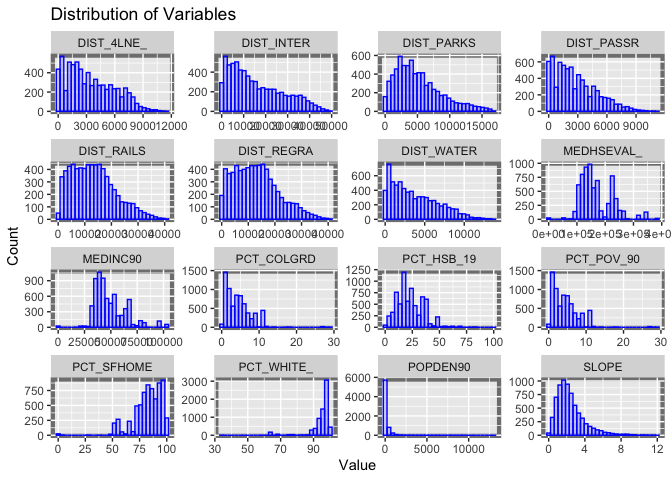

```r
Chester_Numeric %>%
  gather(Variable, Value) %>%
  ggplot(aes(Value)) +
    geom_histogram(bins = 30, color="blue", fill="blue", alpha=0.2) +
    facet_wrap(~Variable, scales = 'free')+
    labs(title = "Distribution of Variables") + ylab("Count")  +
  theme(panel.background = element_rect(colour = "grey50", size=3))
```

Most of the data are highly skewed. We created some dummy variables to adjust the dataset.

The thresholds for the new binary variables are based on their median value in the dataset.

```r
summary(Chester_Numeric)

# REGRAIL300 + CITBORO_10 +
# POPDEN90 + MEDHSEVAL_ + PCT_WHITE_ + PCT_SFHOME + PCT_POV_90 +
# DIST_PASSR + DIST_4LNE_ + DIST_PARKS + DIST_WATER

Chester_bi <-
  Chester_L_Final%>%
  mutate(bi_POV_less4 = case_when(PCT_POV_90 < 4 ~ 1, TRUE ~ 0),
         bi_POPDEN_less60 = case_when(POPDEN90 < 60 ~ 1, TRUE ~ 0),
         bi_WHITE_less97 = case_when(PCT_WHITE_ < 97 ~ 1, TRUE ~ 0),
         bi_SFHOME = case_when(PCT_SFHOME < 86 ~ 1, TRUE ~ 0))
```

```r
#Replace log infinite with NA
Chester_bi <- do.call(data.frame,
               lapply(Chester_bi,
              function(x) replace(x, is.infinite(x), NA)))

#Model
bi_model_bi <- glm(CHNG_URB ~ FOURLNE300 + INTERST800 + REGRAIL300 + RAILSTN100 + CITBORO_10 + PARKS500M + WATER100 +
bi_POPDEN_less60 + MEDHSEVAL_ + bi_WHITE_less97 + bi_SFHOME + bi_POV_less4  + DIST_PASSR + DIST_4LNE_ + DIST_PARKS  + DIST_WATER + DIST_RAILS + DIST_REGRA + DIST_INTER + PCT_HSB_19 + SLOPE + MEDINC90 , family = binomial, data = na.omit(Chester_bi))

summary(bi_model_bi)
```

```
##
## Call:
## glm(formula = CHNG_URB ~ FOURLNE300 + INTERST800 + REGRAIL300 +
##     RAILSTN100 + CITBORO_10 + PARKS500M + WATER100 + bi_POPDEN_less60 +
##     MEDHSEVAL_ + bi_WHITE_less97 + bi_SFHOME + bi_POV_less4 +
##     DIST_PASSR + DIST_4LNE_ + DIST_PARKS + DIST_WATER + DIST_RAILS +
##     DIST_REGRA + DIST_INTER + PCT_HSB_19 + SLOPE + MEDINC90,
##     family = binomial, data = na.omit(Chester_bi))
##
## Deviance Residuals:
##     Min       1Q   Median       3Q      Max
## -1.4204  -0.2662  -0.1513  -0.0847   3.2871
##
## Coefficients: (2 not defined because of singularities)
##                    Estimate Std. Error z value Pr(>|z|)
## (Intercept)      -2.645e+00  8.085e-01  -3.272 0.001068 **
## FOURLNE300        3.350e-01  3.467e-01   0.966 0.333921
## INTERST800        2.924e-01  2.768e-01   1.056 0.290790
## REGRAIL300        3.157e-01  2.605e-01   1.212 0.225590
## RAILSTN100        4.492e-01  4.272e-01   1.051 0.293093
## CITBORO_10        4.939e-01  2.603e-01   1.898 0.057735 .
## PARKS500M                NA         NA      NA       NA
## WATER100                 NA         NA      NA       NA
## bi_POPDEN_less60 -7.440e-01  1.974e-01  -3.769 0.000164 ***
## MEDHSEVAL_        7.207e-07  1.889e-06   0.382 0.702785
## bi_WHITE_less97   6.023e-01  1.946e-01   3.095 0.001970 **
## bi_SFHOME         4.004e-01  2.217e-01   1.806 0.070938 .
## bi_POV_less4      7.059e-01  2.137e-01   3.303 0.000956 ***
## DIST_PASSR       -1.379e-04  6.743e-05  -2.044 0.040908 *
## DIST_4LNE_       -2.581e-04  9.219e-05  -2.800 0.005107 **
## DIST_PARKS       -1.244e-04  4.209e-05  -2.956 0.003121 **
## DIST_WATER        1.866e-05  3.576e-05   0.522 0.601786
## DIST_RAILS        1.821e-04  1.577e-04   1.155 0.248235
## DIST_REGRA       -2.580e-04  1.622e-04  -1.591 0.111706
## DIST_INTER        2.856e-05  2.358e-05   1.211 0.225824
## PCT_HSB_19        1.617e-02  7.314e-03   2.211 0.027047 *
## SLOPE            -1.123e-01  5.172e-02  -2.171 0.029963 *
## MEDINC90         -3.646e-06  9.342e-06  -0.390 0.696354
## ---
## Signif. codes:  0 '***' 0.001 '**' 0.01 '*' 0.05 '.' 0.1 ' ' 1
##
## (Dispersion parameter for binomial family taken to be 1)
##
##     Null deviance: 1763.5  on 5493  degrees of freedom
## Residual deviance: 1376.2  on 5473  degrees of freedom
## AIC: 1418.2
##
## Number of Fisher Scoring iterations: 8
```

```r
#Backward Selection Log

step(glm(CHNG_URB ~ FOURLNE300 + INTERST800 + REGRAIL300 + RAILSTN100 + CITBORO_10 + PARKS500M + WATER100 +
bi_POPDEN_less60 + MEDHSEVAL_ + bi_WHITE_less97 + bi_SFHOME + bi_POV_less4  + DIST_PASSR + DIST_4LNE_ + DIST_PARKS  + DIST_WATER + DIST_RAILS + DIST_REGRA + DIST_INTER + PCT_HSB_19 + SLOPE + MEDINC90 , family = binomial, data = na.omit(Chester_bi)))
```

```
## Start:  AIC=1418.15
## CHNG_URB ~ FOURLNE300 + INTERST800 + REGRAIL300 + RAILSTN100 +
##     CITBORO_10 + PARKS500M + WATER100 + bi_POPDEN_less60 + MEDHSEVAL_ +
##     bi_WHITE_less97 + bi_SFHOME + bi_POV_less4 + DIST_PASSR +
##     DIST_4LNE_ + DIST_PARKS + DIST_WATER + DIST_RAILS + DIST_REGRA +
##     DIST_INTER + PCT_HSB_19 + SLOPE + MEDINC90
##
##
## Step:  AIC=1418.15
## CHNG_URB ~ FOURLNE300 + INTERST800 + REGRAIL300 + RAILSTN100 +
##     CITBORO_10 + PARKS500M + bi_POPDEN_less60 + MEDHSEVAL_ +
##     bi_WHITE_less97 + bi_SFHOME + bi_POV_less4 + DIST_PASSR +
##     DIST_4LNE_ + DIST_PARKS + DIST_WATER + DIST_RAILS + DIST_REGRA +
##     DIST_INTER + PCT_HSB_19 + SLOPE + MEDINC90
##
##
## Step:  AIC=1418.15
## CHNG_URB ~ FOURLNE300 + INTERST800 + REGRAIL300 + RAILSTN100 +
##     CITBORO_10 + bi_POPDEN_less60 + MEDHSEVAL_ + bi_WHITE_less97 +
##     bi_SFHOME + bi_POV_less4 + DIST_PASSR + DIST_4LNE_ + DIST_PARKS +
##     DIST_WATER + DIST_RAILS + DIST_REGRA + DIST_INTER + PCT_HSB_19 +
##     SLOPE + MEDINC90
##
##                    Df Deviance    AIC
## - MEDHSEVAL_        1   1376.3 1416.3
## - MEDINC90          1   1376.3 1416.3
## - DIST_WATER        1   1376.4 1416.4
## - FOURLNE300        1   1377.1 1417.1
## - RAILSTN100        1   1377.2 1417.2
## - INTERST800        1   1377.3 1417.3
## - DIST_RAILS        1   1377.5 1417.5
## - REGRAIL300        1   1377.6 1417.6
## - DIST_INTER        1   1377.6 1417.6
## <none>                  1376.2 1418.2
## - DIST_REGRA        1   1378.6 1418.6
## - bi_SFHOME         1   1379.5 1419.5
## - CITBORO_10        1   1379.6 1419.6
## - DIST_PASSR        1   1380.5 1420.5
## - PCT_HSB_19        1   1381.0 1421.0
## - SLOPE             1   1381.1 1421.1
```

[output cut: 185 more lines]

```
##
##                    Df Deviance    AIC
## <none>                  1381.7 1407.7
## - CITBORO_10        1   1385.5 1409.5
## - DIST_PASSR        1   1386.6 1410.6
## - REGRAIL300        1   1387.4 1411.4
## - SLOPE             1   1388.0 1412.0
## - bi_SFHOME         1   1388.3 1412.3
## - PCT_HSB_19        1   1388.5 1412.5
## - DIST_PARKS        1   1389.5 1413.5
## - DIST_REGRA        1   1393.8 1417.8
## - bi_WHITE_less97   1   1394.7 1418.7
## - bi_POV_less4      1   1395.9 1419.9
## - bi_POPDEN_less60  1   1399.0 1423.0
## - DIST_4LNE_        1   1426.4 1450.4
```

```
##
## Call:  glm(formula = CHNG_URB ~ REGRAIL300 + CITBORO_10 + bi_POPDEN_less60 +
##     bi_WHITE_less97 + bi_SFHOME + bi_POV_less4 + DIST_PASSR +
##     DIST_4LNE_ + DIST_PARKS + DIST_REGRA + PCT_HSB_19 + SLOPE,
##     family = binomial, data = na.omit(Chester_bi))
##
## Coefficients:
##      (Intercept)        REGRAIL300        CITBORO_10  bi_POPDEN_less60
##       -2.058e+00         5.374e-01         5.143e-01        -7.720e-01
##  bi_WHITE_less97         bi_SFHOME      bi_POV_less4        DIST_PASSR
##        6.455e-01         4.322e-01         7.283e-01        -1.372e-04
##       DIST_4LNE_        DIST_PARKS        DIST_REGRA        PCT_HSB_19
##       -3.400e-04        -9.565e-05        -5.521e-05         1.718e-02
##            SLOPE
##       -1.233e-01
##
## Degrees of Freedom: 5493 Total (i.e. Null);  5481 Residual
## Null Deviance:       1763
## Residual Deviance: 1382  AIC: 1408
```

```r
#Forward Selection log
fullmod2<-glm(glm(CHNG_URB ~ FOURLNE300 + INTERST800 + REGRAIL300 + RAILSTN100 + CITBORO_10 + PARKS500M + WATER100 +
bi_POPDEN_less60 + MEDHSEVAL_ + bi_WHITE_less97 + bi_SFHOME + bi_POV_less4  + DIST_PASSR + DIST_4LNE_ + DIST_PARKS  + DIST_WATER + DIST_RAILS + DIST_REGRA + DIST_INTER + PCT_HSB_19 + SLOPE + MEDINC90 , family = binomial, data = na.omit(Chester_bi)))

intonly2<-glm(CHNG_URB ~ 1, family = binomial, data = na.omit(Chester_bi))

step(intonly2, scope=list(lower=intonly2, upper=fullmod2), direction="forward")
```

```
## Start:  AIC=1765.48
## CHNG_URB ~ 1
##
##                    Df Deviance    AIC
## + DIST_4LNE_        1   1580.4 1584.4
## + DIST_REGRA        1   1602.9 1606.9
## + DIST_RAILS        1   1605.1 1609.1
## + FOURLNE300        1   1612.0 1616.0
## + REGRAIL300        1   1614.2 1618.2
## + DIST_PASSR        1   1653.6 1657.6
## + bi_POPDEN_less60  1   1674.7 1678.7
## + DIST_INTER        1   1696.1 1700.1
## + bi_POV_less4      1   1705.5 1709.5
## + INTERST800        1   1718.1 1722.1
## + bi_WHITE_less97   1   1720.0 1724.0
## + CITBORO_10        1   1723.6 1727.6
## + RAILSTN100        1   1725.0 1729.0
## + DIST_PARKS        1   1725.2 1729.2
## + MEDHSEVAL_        1   1738.4 1742.4
## + DIST_WATER        1   1743.3 1747.3
## + MEDINC90          1   1745.3 1749.3
## + PCT_HSB_19        1   1749.9 1753.9
## + bi_SFHOME         1   1756.7 1760.7
## <none>                  1763.5 1765.5
## + SLOPE             1   1763.5 1767.5
##
## Step:  AIC=1584.44
## CHNG_URB ~ DIST_4LNE_
##
##                    Df Deviance    AIC
## + DIST_REGRA        1   1500.6 1506.6
## + DIST_RAILS        1   1501.0 1507.0
## + REGRAIL300        1   1510.0 1516.0
## + bi_POPDEN_less60  1   1522.4 1528.4
## + DIST_PASSR        1   1545.6 1551.6
## + DIST_INTER        1   1551.4 1557.4
## + bi_POV_less4      1   1553.0 1559.0
## + CITBORO_10        1   1553.3 1559.3
## + DIST_PARKS        1   1559.0 1565.0
## + RAILSTN100        1   1561.0 1567.0
```

[output cut: 216 more lines]

```
## Step:  AIC=1407.65
## CHNG_URB ~ DIST_4LNE_ + DIST_REGRA + bi_POPDEN_less60 + CITBORO_10 +
##     DIST_PASSR + bi_POV_less4 + bi_WHITE_less97 + bi_SFHOME +
##     DIST_PARKS + PCT_HSB_19 + SLOPE + REGRAIL300
##
##              Df Deviance    AIC
## <none>            1381.7 1407.7
## + DIST_RAILS  1   1380.6 1408.6
## + FOURLNE300  1   1380.7 1408.7
## + DIST_WATER  1   1380.8 1408.8
## + RAILSTN100  1   1380.9 1408.9
## + MEDHSEVAL_  1   1381.3 1409.3
## + INTERST800  1   1381.4 1409.4
## + DIST_INTER  1   1381.5 1409.5
## + MEDINC90    1   1381.7 1409.7
```

```
##
## Call:  glm(formula = CHNG_URB ~ DIST_4LNE_ + DIST_REGRA + bi_POPDEN_less60 +
##     CITBORO_10 + DIST_PASSR + bi_POV_less4 + bi_WHITE_less97 +
##     bi_SFHOME + DIST_PARKS + PCT_HSB_19 + SLOPE + REGRAIL300,
##     family = binomial, data = na.omit(Chester_bi))
##
## Coefficients:
##      (Intercept)        DIST_4LNE_        DIST_REGRA  bi_POPDEN_less60
##       -2.058e+00        -3.400e-04        -5.521e-05        -7.720e-01
##       CITBORO_10        DIST_PASSR      bi_POV_less4   bi_WHITE_less97
##        5.143e-01        -1.372e-04         7.283e-01         6.455e-01
##        bi_SFHOME        DIST_PARKS        PCT_HSB_19             SLOPE
##        4.322e-01        -9.565e-05         1.718e-02        -1.233e-01
##       REGRAIL300
##        5.374e-01
##
## Degrees of Freedom: 5493 Total (i.e. Null);  5481 Residual
## Null Deviance:       1763
## Residual Deviance: 1382  AIC: 1408
```

```r
CHNG_URB ~ DIST_4LNE_ + DIST_REGRA + bi_POPDEN_less60 + CITBORO_10 +
    DIST_PASSR + bi_POV_less4 + bi_WHITE_less97 + bi_SFHOME +
    DIST_PARKS + PCT_HSB_19 + SLOPE + REGRAIL300
```

```
## CHNG_URB ~ DIST_4LNE_ + DIST_REGRA + bi_POPDEN_less60 + CITBORO_10 +
##     DIST_PASSR + bi_POV_less4 + bi_WHITE_less97 + bi_SFHOME +
##     DIST_PARKS + PCT_HSB_19 + SLOPE + REGRAIL300
```

```r
CHNG_URB ~ REGRAIL300 + CITBORO_10 + bi_POPDEN_less60 + bi_WHITE_less97 + bi_SFHOME + bi_POV_less4 + DIST_PASSR + DIST_4LNE_ + DIST_PARKS +
  DIST_REGRA + PCT_HSB_19 + SLOPE
```

```
## CHNG_URB ~ REGRAIL300 + CITBORO_10 + bi_POPDEN_less60 + bi_WHITE_less97 +
##     bi_SFHOME + bi_POV_less4 + DIST_PASSR + DIST_4LNE_ + DIST_PARKS +
##     DIST_REGRA + PCT_HSB_19 + SLOPE
```

The forward and backward selection methods gave the same set of the most relevant variables for determining probability of urbanization.

```r
bi_model_bi2 <- glm(formula = CHNG_URB ~ DIST_4LNE_ + DIST_REGRA + bi_POPDEN_less60 +  CITBORO_10 + DIST_PASSR + bi_POV_less4 + bi_WHITE_less97 + bi_SFHOME + DIST_PARKS + PCT_HSB_19 + SLOPE + REGRAIL300, family = binomial, data = na.omit(Chester_bi))

summary(bi_model_bi2)
```

```
##
## Call:
## glm(formula = CHNG_URB ~ DIST_4LNE_ + DIST_REGRA + bi_POPDEN_less60 +
##     CITBORO_10 + DIST_PASSR + bi_POV_less4 + bi_WHITE_less97 +
##     bi_SFHOME + DIST_PARKS + PCT_HSB_19 + SLOPE + REGRAIL300,
##     family = binomial, data = na.omit(Chester_bi))
##
## Deviance Residuals:
##     Min       1Q   Median       3Q      Max
## -1.3609  -0.2676  -0.1516  -0.0838   3.2712
##
## Coefficients:
##                    Estimate Std. Error z value Pr(>|z|)
## (Intercept)      -2.058e+00  4.307e-01  -4.779 1.76e-06 ***
## DIST_4LNE_       -3.400e-04  5.589e-05  -6.084 1.17e-09 ***
## DIST_REGRA       -5.521e-05  1.656e-05  -3.334 0.000857 ***
## bi_POPDEN_less60 -7.720e-01  1.956e-01  -3.948 7.89e-05 ***
## CITBORO_10        5.143e-01  2.555e-01   2.013 0.044165 *
## DIST_PASSR       -1.372e-04  6.335e-05  -2.166 0.030326 *
## bi_POV_less4      7.283e-01  1.987e-01   3.666 0.000247 ***
## bi_WHITE_less97   6.455e-01  1.818e-01   3.550 0.000385 ***
## bi_SFHOME         4.322e-01  1.680e-01   2.572 0.010110 *
## DIST_PARKS       -9.565e-05  3.467e-05  -2.759 0.005796 **
## PCT_HSB_19        1.718e-02  6.514e-03   2.637 0.008368 **
## SLOPE            -1.233e-01  5.020e-02  -2.455 0.014077 *
## REGRAIL300        5.374e-01  2.242e-01   2.397 0.016537 *
## ---
## Signif. codes:  0 '***' 0.001 '**' 0.01 '*' 0.05 '.' 0.1 ' ' 1
##
## (Dispersion parameter for binomial family taken to be 1)
##
##     Null deviance: 1763.5  on 5493  degrees of freedom
## Residual deviance: 1381.7  on 5481  degrees of freedom
## AIC: 1407.7
##
## Number of Fisher Scoring iterations: 7
```

```r
vif(bi_model_bi2)
```

```
##       DIST_4LNE_       DIST_REGRA bi_POPDEN_less60       CITBORO_10
##         1.146723         2.215348         1.074725         1.465559
##       DIST_PASSR     bi_POV_less4  bi_WHITE_less97        bi_SFHOME
##         1.364742         1.500934         1.296667         1.243636
##       DIST_PARKS       PCT_HSB_19            SLOPE       REGRAIL300
##         1.140865         1.778752         1.127990         2.064320
```

The AIC is 1408 of the final model and the VIF is all well below 5, meaning there are no co-linear variables.

```r
qchisq(.95, df=5493)
```

```
## [1] 5666.533
```

The critical value is 5666.5. The null deviance value of the model (1763) is much lower than the critical value, meaning our predicted results will be in a similar range as the observations.

*The model with more binary variables is more reliable to predict the results.*

```r
exp(coef(bi_model_bi2))
```

```
##      (Intercept)       DIST_4LNE_       DIST_REGRA bi_POPDEN_less60
##        0.1276805        0.9996600        0.9999448        0.4620714
##       CITBORO_10       DIST_PASSR     bi_POV_less4  bi_WHITE_less97
##        1.6724169        0.9998628        2.0715963        1.9069320
##        bi_SFHOME       DIST_PARKS       PCT_HSB_19            SLOPE
##        1.5405673        0.9999044        1.0173247        0.8840269
##       REGRAIL300
##        1.7115608
```

```r
100 * (exp(coef(bi_model_bi2))-1)
```

```
##      (Intercept)       DIST_4LNE_       DIST_REGRA bi_POPDEN_less60
##    -87.231954376     -0.033997550     -0.005521312    -53.792860774
##       CITBORO_10       DIST_PASSR     bi_POV_less4  bi_WHITE_less97
##     67.241691701     -0.013719095    107.159627127     90.693204811
##        bi_SFHOME       DIST_PARKS       PCT_HSB_19            SLOPE
##     54.056730009     -0.009564258      1.732467015    -11.597306380
##       REGRAIL300
##     71.156079555
```

The fact that an area has less than 4% of the households living below poverty line is associated with a *107% increase* in the odd ratio. The odd ratio is the possibility of success over possibility of failure. A decrease in the odd ratio means that the location will households less chance to turn into a urban area when the percent of households living in poverty increases.

The fact that an area is located within 300 meters of a SEPTA railway is associated with *71% increase* in chance of successfully being urbanized.

If a location is within 1000 meters of another city or boro, the chance of being urbanized is *increased by 67%*.

## 1.7 Other suggestions

Some additional data could be gathered, such as the population density, household income, and median housing value from 2000 census. The demographic and economic growth rates could be another huge factor for urbanization. These could be more relevant variables to determine probability of land use.

## 1.8 Conclusion with Plots and Tables

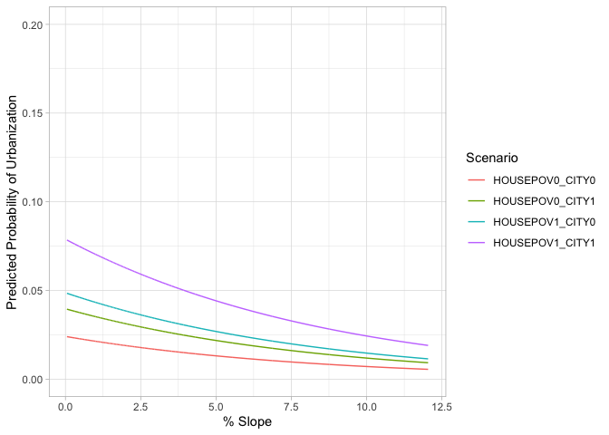

```r
#Holding everything else constant, but percent poverty

## 0 in household poverty below 4%

POV_possibility <- data.frame(bi_POV_less4 = 0, REGRAIL300 = 1, CITBORO_10 = 1, bi_POPDEN_less60 = 1, bi_WHITE_less97 = 1, bi_SFHOME = 1, DIST_4LNE_ = mean(Chester_bi$DIST_4LNE_,na.rm = TRUE), DIST_PARKS = mean(Chester_bi$DIST_PARKS,na.rm = TRUE), DIST_REGRA = mean(Chester_bi$DIST_REGRA,na.rm = TRUE), DIST_PASSR = mean(Chester_bi$DIST_PASSR, na.rm = TRUE), PCT_HSB_19 = mean(Chester_bi$PCT_HSB_19), SLOPE = Chester_bi$SLOPE)

POV_possibility <-
  POV_possibility %>%
  mutate(predict_result = predict(bi_model_bi2,POV_possibility,type = "response"))

## 1 in household poverty below 4%
POV_possibility2 <- data.frame(bi_POV_less4 = 1, REGRAIL300 = 1, CITBORO_10 = 1, bi_POPDEN_less60 = 1, bi_WHITE_less97 = 1, bi_SFHOME = 1, DIST_4LNE_ = mean(Chester_bi$DIST_4LNE_,na.rm = TRUE), DIST_PARKS = mean(Chester_bi$DIST_PARKS,na.rm = TRUE), DIST_REGRA = mean(Chester_bi$DIST_REGRA,na.rm = TRUE), DIST_PASSR = mean(Chester_bi$DIST_PASSR, na.rm = TRUE), PCT_HSB_19 = mean(Chester_bi$PCT_HSB_19), SLOPE = Chester_bi$SLOPE)

POV_possibility2 <-
  POV_possibility2 %>%
  mutate(predict_result = predict(bi_model_bi2,POV_possibility2,type = "response"))

##  0 in household poverty below 4% and 0 in city
POV_possibility3 <- data.frame(bi_POV_less4 = 0, REGRAIL300 = 1, CITBORO_10 = 0, bi_POPDEN_less60 = 1, bi_WHITE_less97 = 1, bi_SFHOME = 1, DIST_4LNE_ = mean(Chester_bi$DIST_4LNE_,na.rm = TRUE), DIST_PARKS = mean(Chester_bi$DIST_PARKS,na.rm = TRUE), DIST_REGRA = mean(Chester_bi$DIST_REGRA,na.rm = TRUE), DIST_PASSR = mean(Chester_bi$DIST_PASSR, na.rm = TRUE), PCT_HSB_19 = mean(Chester_bi$PCT_HSB_19), SLOPE = Chester_bi$SLOPE)

POV_possibility3 <-
  POV_possibility3 %>%
  mutate(predict_result = predict(bi_model_bi2,POV_possibility3,type = "response"))

## 1 in household poverty below % and 0 in city
POV_possibility4 <- data.frame(bi_POV_less4 = 1, REGRAIL300 = 1, CITBORO_10 = 0, bi_POPDEN_less60 = 1, bi_WHITE_less97 = 1, bi_SFHOME = 1, DIST_4LNE_ = mean(Chester_bi$DIST_4LNE_,na.rm = TRUE), DIST_PARKS = mean(Chester_bi$DIST_PARKS,na.rm = TRUE), DIST_REGRA = mean(Chester_bi$DIST_REGRA,na.rm = TRUE), DIST_PASSR = mean(Chester_bi$DIST_PASSR, na.rm = TRUE), PCT_HSB_19 = mean(Chester_bi$PCT_HSB_19), SLOPE = Chester_bi$SLOPE)

POV_possibility4 <-
  POV_possibility4 %>%
  mutate(predict_result = predict(bi_model_bi2,POV_possibility4,type = "response"))


#Combing the results in a new data frame
POV_PRE <- data.frame(SLOPE = POV_possibility$SLOPE,
HOUSEPOV0_CITY1 = POV_possibility$predict_result,
HOUSEPOV1_CITY1 = POV_possibility2$predict_result,
HOUSEPOV0_CITY0 = POV_possibility3$predict_result,
HOUSEPOV1_CITY0 = POV_possibility4$predict_result)

#Arrange the data by scenario
dat <- gather(POV_PRE, -SLOPE, key = "Scenario", value = "value")
#Plot the data

ggplot(dat, aes(x = SLOPE, y = value, colour = Scenario)) +
        geom_line() + ylim(0,0.2) +
        xlab("% Slope") + ylab("Predicted Probability of Urbanization") + theme_light()
```

While holding every other variable constant (with their mean values), the graph above shows the predicting results when changing factor whether the location has less than 4 percent of households living below poverty line and within 1000 meters of a city or boro.

All the curves are plotted against the change in slope

The graph also shows as the percent slope increases, the predicted probably of urbanization decreases as well.

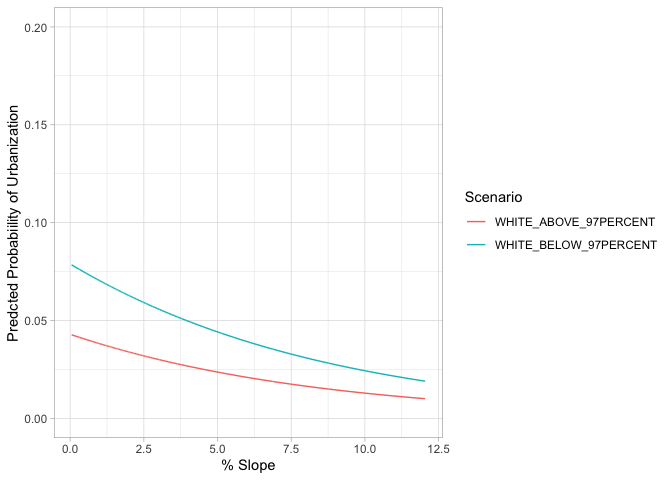

```r
#Holding everything else constant, but percent poverty

## 0 in white

WHI_possibility <- data.frame(bi_POV_less4 = 1, REGRAIL300 = 1, CITBORO_10 = 1, bi_POPDEN_less60 = 1, bi_WHITE_less97 = 0, bi_SFHOME = 1, DIST_4LNE_ = mean(Chester_bi$DIST_4LNE_,na.rm = TRUE), DIST_PARKS = mean(Chester_bi$DIST_PARKS,na.rm = TRUE), DIST_REGRA = mean(Chester_bi$DIST_REGRA,na.rm = TRUE), DIST_PASSR = mean(Chester_bi$DIST_PASSR, na.rm = TRUE), PCT_HSB_19 = mean(Chester_bi$PCT_HSB_19), SLOPE = Chester_bi$SLOPE)

WHI_possibility <-
  POV_possibility %>%
  mutate(predict_result = predict(bi_model_bi2,WHI_possibility,type = "response"))

## 1 in white
WHI_possibility2 <- data.frame(bi_POV_less4 = 1, REGRAIL300 = 1, CITBORO_10 = 1, bi_POPDEN_less60 = 1, bi_WHITE_less97 = 1, bi_SFHOME = 1, DIST_4LNE_ = mean(Chester_bi$DIST_4LNE_,na.rm = TRUE), DIST_PARKS = mean(Chester_bi$DIST_PARKS,na.rm = TRUE), DIST_REGRA = mean(Chester_bi$DIST_REGRA,na.rm = TRUE), DIST_PASSR = mean(Chester_bi$DIST_PASSR, na.rm = TRUE), PCT_HSB_19 = mean(Chester_bi$PCT_HSB_19), SLOPE = Chester_bi$SLOPE)

WHI_possibility2 <-
  POV_possibility2 %>%
  mutate(predict_result = predict(bi_model_bi2,WHI_possibility2,type = "response"))

#Combing the results in a new data frame
WHI_PRE <- data.frame(SLOPE = WHI_possibility$SLOPE, WHITE_ABOVE_97PERCENT = WHI_possibility$predict_result, WHITE_BELOW_97PERCENT = WHI_possibility2$predict_result)

#Arrange the data by scenario
dat <- gather(WHI_PRE, -SLOPE, key = "Scenario", value = "value")
#Plot the data

ggplot(dat, aes(x = SLOPE, y = value, colour = Scenario)) +
        geom_line() + ylim(0,0.2) +
        xlab("% Slope") + ylab("Predcted Probabiility of Urbanization") + theme_light()
```

The above graph shows the predicted probability of urbanization when the percent of white population is either below or above 97% in a given location in 1990 against percent slope.

The graph shows that, in Chester County, those areas that lived with less white population in 1990 had a higher chance of being urbanized in 2001 based on the graph.

# 2 Part 2: Modelling Commute Mode Choice

In this report, we model the following using trip data from the Delaware Valley Regional Planning Commission:  
1. Whether a commuter drove to work  
2. Whether a commuter walked or biked to work  
3. Whether a commuter drove to work, carpooled, took public transit, or walked or biked

```r
# Read Chester land use Data and its geometry

trips <- read.csv("HH Travel Survey/trip_pub.csv") %>%
 # filter(ACT1 == 11 | ACT1 ==12) %>% #filter for work trips
  mutate(drove_work = ifelse(TRAN1 == 21, 1, 0),
         bike_walk_work = ifelse(TRAN1 == 11 | TRAN1 == 14, 1, 0),
         transit_work = ifelse(TRAN1 == 41 | TRAN1 == 44 | TRAN1 == 47 | TRAN1 == 51 | TRAN1 == 52 | TRAN1 == 53, 1, 0),
         carpool_work = ifelse(TRAN1 == 31, 1,0),
         )
# %>%
#   dplyr::select(-DVRPC, -SPDFLAG, -OEGRES, -EGRESS, -EXIT, -OTRFS, -FARE3, -PAY3O, -PAY3, -TRFL2, -TRFS2, -FARE2, -PAY2O, -PAY2, -TRFL1, -TRFS1, -TRFR, -FARE1, -PAY1O, -PAY1, -LINE, -OACESS, -ACCESS, -SUBTR, -APDPN, -APDPH, -ADDPN, -ADDPH, -ADDP, -TOLLA, -TOLL, -PRKUO, -NNHTR, -PHHTR, -ADP, -HHVU, -OTRAN, -PLANO, -X, -ACT2, -ACT3, -ACT4, -ACT5, -ACT6, -ACT1O, -ACTO, -TRAN4, -TRAN3, -PARKO, -APDP, -X.1, -TRAN1, -TRAN2)

households <- read.csv("HH Travel Survey/hh_pub_CSV.csv", header = TRUE) %>%
  dplyr::select(ADVLT, TOTVEH, DWELL, YRMOV, RENT, DIARY, ENGL, HHSIZE, NPHON, NOPHO, SHPHN, ETHNC, INCLV, INCOM, INCOME, ASSN, DPHON, NPLAC, NTRIPS, NOWRK, NOSTU, OWNSH, EACCT, CPA, DAYOFWK, HBW, HBO, NHB, MOTTRIP, SAMPN, LISTD, HADDR)

persons <- read.csv("HH Travel Survey/per_pub.csv") %>%
  dplyr::select(SAMPN, PERNO, GEND, AGE, LIC, RESP, RELAT, DISAB, DISTY1, DISTY2, EDUC, SHOME, SDAY, SMODE1)
```

First, we clean the data and merge three datasets capturing participants’ trip, household, and demographic attributes. We clean out NAs, and filter the data to make sure the values are all in the correct ranges.

```r
trips$drove_work[which(is.na(trips$drove_work))]<-0
trips$bike_walk_work[which(is.na(trips$bike_walk_work))]<-0
trips$transit_work[which(is.na(trips$transit_work))]<-0
trips$carpool_work[which(is.na(trips$carpool_work))]<-0
trips$SUMZERO<- trips$drove_work + trips$bike_walk_work + trips$transit_work + trips$carpool_work
trips <- trips[-which(trips$SUMZERO == 0), ]

trips <- trips[which(trips$Dest_PTYE == 2), ]
trips$Commute[trips$drove_work == 1] <- 1
trips$Commute[trips$bike_walk_work == 1] <- 2
trips$Commute[trips$transit_work == 1] <- 3
trips$Commute[trips$carpool_work == 1] <- 4


trips$SAMPN_PER <- do.call(paste, c(trips[c("SAMPN", "PERNO")], sep = ""))
trips <- subset(trips, !duplicated(SAMPN_PER))

person_hh <- merge(persons, households,
                    by.x = "SAMPN",
                    by.y = "SAMPN",
                    all.x = TRUE,
                    all.y=FALSE,
                    sort = FALSE)
# colnamCleaning<-c("VETMO", "W2TY", "W2TYO",  "W2TYP", "W2LOC", "W2IND", "W2INO", "W2OCC", "W2OCO", "W2DAY", "W2HOM", "W2HOO", "W2ST", "W2ET",  "W1WKD3", "W1WKD4", "W1WKE", "W1WKD1", "W1WKD2")
# person_hh<-person_hh[ , -which(names(persons) %in% colnamCleaning)]

person_hh$SAMPN_PER <- do.call(paste, c(person_hh[c("SAMPN", "PERNO")], sep = ""))

trips_person_hh <- merge(trips, person_hh,
                            by.x = "SAMPN_PER",
                            by.y = "SAMPN_PER",
                            all.x = TRUE,
                            all.y=FALSE,
                            sort = FALSE)

# varsInterest <- c("SAMPN", "PERNO", "AGE", "GENDER", "INCOME", "SAMPN_PER", "TOLLA", "TOLL", "PARKC", "PARKU", "PRKUO", "TRPDUR", "drove_work", "bike_walk_work", "transit_work", "carpool_work", "Commute")
# trips_person_hh<-trips_person_hh[ , which(names(trips_person_hh) %in% varsInterest)]

# trips_person_hh<-trips_person_hh[-which(is.na(trips_person_hh$INCOME)),]

drive<-trips_person_hh[which(trips_person_hh$drove_work ==1),]
walk_bike<-trips_person_hh[which(trips_person_hh$bike_walk_work ==1),]
transit<-trips_person_hh[which(trips_person_hh$transit_work ==1),]
carpool<-trips_person_hh[which(trips_person_hh$carpool_work ==1),]


summary(drive$TRPDUR)     #mean: 26
summary(walk_bike$TRPDUR) #mean: 21
summary(transit$TRPDUR)   #mean: 51
summary(carpool$TRPDUR)   #mean: 40

drive$distance<-(30/60)*drive$TRPDUR
walk_bike$distance<-(12/60)*walk_bike$TRPDUR
transit$distance<-(25/60)*transit$TRPDUR
carpool$distance<-(30/60)*carpool$TRPDUR

#re-combine the three data sets
dat<-rbind(drive, walk_bike, transit, carpool)

#potential times for each
dat$time.auto <-dat$distance/30
dat$time.bike.walk <- dat$distance/12
dat$time.transit <- dat$distance/25
dat$time.carpool <- dat$distance/30

dat$mode[dat$drove_work == 1] <- "drove"
dat$mode[dat$transit_work == 1] <- "transit"
dat$mode[dat$bike_walk_work == 1] <- "bike"
dat$mode[dat$carpool_work == 1] <- "carpool"

rownames(dat) <- NULL
#
# varsInterest <- c("AGE", "GENDER", "INCOME", "time.auto", "time.bike.walk", "time.transit", "time.carpool", "mode")
# dat<-dat[ , which(names(dat) %in% varsInterest)]

#clean data further
trips_person_hh <-trips_person_hh[which(trips_person_hh$AGE %in% 1:110),]
trips_person_hh <-trips_person_hh[which(trips_person_hh$TRPDUR %in% 0:400),]
trips_person_hh <-trips_person_hh[which(trips_person_hh$INCOME %in% 0:200000),]
```

## 2.1 Binary Logit: Driving, Biking, and Walking to Work

### 2.1.1 Model 1: Drive to Work

First, we test a model using the maximum number of variables, just as a baseline. This model includes trip duration, gender, age, disability, education, total vehicles in a household, adults in household, rent or not, whether they speak English, household size, number of phones in the household, income, and whether a household has working adults. The AIC is 1493, with just about half of the variables marked as statistically significant.

```r
mod_drive <- glm ( drove_work ~  TRPDUR  + GEND + AGE+DISAB+EDUC + TOTVEH + ADVLT + RENT + ENGL + HHSIZE + NPHON + INCOME + NOWRK, data=trips_person_hh, family = binomial)
summary(mod_drive)

#take out some outliers
trips_person_hh <-trips_person_hh[which(trips_person_hh$AGE %in% 1:110),]
trips_person_hh <-trips_person_hh[which(trips_person_hh$TRPDUR %in% 0:400),]
trips_person_hh <-trips_person_hh[which(trips_person_hh$INCOME %in% 0:200000),]
```

[output not shown]

Using vif(), we can see that the variance inflation factor for all variables is below 5, meaning the model does not suffer from too much collinearity.

```r
vif(mod_drive)
```

```
##   TRPDUR     GEND      AGE    DISAB     EDUC   TOTVEH    ADVLT     RENT
## 1.025864 1.021570 1.222729 1.007698 1.102111 1.858384 1.003979 1.202719
##     ENGL   HHSIZE    NPHON   INCOME    NOWRK
## 1.000000 1.690689 1.160306 1.327662 2.056474
```

To create the “leanest and meanest” model, we use forward and backward selection to select the variables which contribute statistically significantly to the model and lower its AIC.

```r
#Backward Selection
step(glm(drove_work ~  TRPDUR  + GEND + AGE+DISAB+EDUC + TOTVEH + ADVLT + RENT + ENGL + HHSIZE + NPHON + INCOME + NOWRK, data=trips_person_hh), direction = "backward")
```

```
## Start:  AIC=916.89
## drove_work ~ TRPDUR + GEND + AGE + DISAB + EDUC + TOTVEH + ADVLT +
##     RENT + ENGL + HHSIZE + NPHON + INCOME + NOWRK
##
##          Df Deviance     AIC
## - NPHON   1   231.59  914.93
## - ENGL    1   231.60  915.08
## - ADVLT   1   231.63  915.39
## - HHSIZE  1   231.63  915.45
## - DISAB   1   231.67  915.93
## <none>        231.59  916.89
## - INCOME  1   231.79  917.51
## - EDUC    1   232.01  920.27
## - AGE     1   232.02  920.38
## - GEND    1   232.05  920.69
## - RENT    1   233.47  938.60
## - NOWRK   1   235.04  958.08
## - TRPDUR  1   236.62  977.60
## - TOTVEH  1   253.41 1177.82
##
## Step:  AIC=914.93
## drove_work ~ TRPDUR + GEND + AGE + DISAB + EDUC + TOTVEH + ADVLT +
##     RENT + ENGL + HHSIZE + INCOME + NOWRK
##
##          Df Deviance     AIC
## - ENGL    1   231.60  913.11
## - ADVLT   1   231.63  913.42
## - HHSIZE  1   231.63  913.47
## - DISAB   1   231.67  913.96
## <none>        231.59  914.93
## - INCOME  1   231.82  915.82
## - EDUC    1   232.01  918.28
## - AGE     1   232.03  918.42
## - GEND    1   232.05  918.70
## - RENT    1   233.48  936.68
## - NOWRK   1   235.04  956.08
## - TRPDUR  1   236.62  975.60
## - TOTVEH  1   253.82 1180.46
##
## Step:  AIC=913.11
```

[output cut: 49 more lines]

```
##
## Step:  AIC=909.2
## drove_work ~ TRPDUR + GEND + AGE + EDUC + TOTVEH + RENT + INCOME +
##     NOWRK
##
##          Df Deviance     AIC
## <none>        231.77  909.20
## - INCOME  1   232.00  910.16
## - EDUC    1   232.18  912.32
## - GEND    1   232.21  912.69
## - AGE     1   232.31  913.98
## - RENT    1   233.64  930.66
## - NOWRK   1   236.09  961.09
## - TRPDUR  1   236.82  970.10
## - TOTVEH  1   254.16 1176.39
```

```
##
## Call:  glm(formula = drove_work ~ TRPDUR + GEND + AGE + EDUC + TOTVEH +
##     RENT + INCOME + NOWRK, data = trips_person_hh)
##
## Coefficients:
## (Intercept)       TRPDUR         GEND          AGE         EDUC       TOTVEH
##   5.822e-01   -2.127e-03   -2.470e-02    1.216e-03    4.262e-02    1.035e-01
##        RENT       INCOME        NOWRK
##   6.965e-02    2.518e-07   -5.727e-02
##
## Degrees of Freedom: 2918 Total (i.e. Null);  2910 Residual
## Null Deviance:       271.5
## Residual Deviance: 231.8     AIC: 909.2
```

```r
#Forward Selection
fullmod<-glm(drove_work ~ TRPDUR  + GEND + AGE+DISAB+EDUC + TOTVEH + ADVLT + RENT + ENGL + HHSIZE + NPHON + INCOME + NOWRK, family = binomial, data = trips_person_hh)

intonly<-glm(drove_work ~ 1, family = binomial, data = trips_person_hh)

step(intonly, scope=list(lower=intonly, upper=fullmod), direction="forward")
```

```
## Start:  AIC=1948.15
## drove_work ~ 1
##
##          Df Deviance    AIC
## + TOTVEH  1   1608.7 1612.7
## + RENT    1   1873.2 1877.2
## + TRPDUR  1   1891.2 1895.2
## + INCOME  1   1905.0 1909.0
## + AGE     1   1924.6 1928.6
## + NPHON   1   1928.5 1932.5
## + EDUC    1   1938.9 1942.9
## + NOWRK   1   1939.3 1943.3
## + GEND    1   1939.4 1943.4
## + HHSIZE  1   1940.2 1944.2
## <none>        1946.2 1948.2
## + ENGL    1   1945.0 1949.0
## + ADVLT   1   1945.7 1949.7
## + DISAB   1   1945.7 1949.7
##
## Step:  AIC=1612.66
## drove_work ~ TOTVEH
##
##          Df Deviance    AIC
## + NOWRK   1   1532.6 1538.6
## + TRPDUR  1   1571.8 1577.8
## + HHSIZE  1   1579.9 1585.9
## + AGE     1   1581.6 1587.6
## + EDUC    1   1593.3 1599.3
## + RENT    1   1601.6 1607.6
## <none>        1608.7 1612.7
## + INCOME  1   1606.9 1612.9
## + DISAB   1   1607.1 1613.1
## + GEND    1   1607.1 1613.1
## + NPHON   1   1607.3 1613.3
## + ENGL    1   1607.8 1613.8
## + ADVLT   1   1608.6 1614.6
##
## Step:  AIC=1538.64
## drove_work ~ TOTVEH + NOWRK
##
```

[output cut: 68 more lines]

```
## + INCOME  1   1473.3 1489.3
## + ADVLT   1   1473.5 1489.5
## + NPHON   1   1473.5 1489.5
##
## Step:  AIC=1486.87
## drove_work ~ TOTVEH + NOWRK + TRPDUR + AGE + EDUC + RENT + GEND
##
##          Df Deviance    AIC
## <none>        1470.9 1486.9
## + DISAB   1   1469.2 1487.2
## + ENGL    1   1469.5 1487.5
## + HHSIZE  1   1469.8 1487.8
## + INCOME  1   1470.6 1488.6
## + ADVLT   1   1470.8 1488.8
## + NPHON   1   1470.9 1488.9
```

```
##
## Call:  glm(formula = drove_work ~ TOTVEH + NOWRK + TRPDUR + AGE + EDUC +
##     RENT + GEND, family = binomial, data = trips_person_hh)
##
## Coefficients:
## (Intercept)       TOTVEH        NOWRK       TRPDUR          AGE         EDUC
##    -0.70445      1.71772     -0.87879     -0.01875      0.01446      0.53137
##        RENT         GEND
##     0.35146     -0.22761
##
## Degrees of Freedom: 2918 Total (i.e. Null);  2911 Residual
## Null Deviance:       1946
## Residual Deviance: 1471  AIC: 1487
```

```r
#lowest aic: 1493, vars: TOTVEH + NOWRK + TRPDUR + AGE + GEND

mod_drive_3 <- glm(drove_work ~ TOTVEH + NOWRK + TRPDUR + AGE + EDUC + RENT, family = binomial, data = trips_person_hh)
summary(mod_drive_3)
```

```
##
## Call:
## glm(formula = drove_work ~ TOTVEH + NOWRK + TRPDUR + AGE + EDUC +
##     RENT, family = binomial, data = trips_person_hh)
##
## Deviance Residuals:
##     Min       1Q   Median       3Q      Max
## -4.7670   0.1488   0.3077   0.4340   1.9013
##
## Coefficients:
##              Estimate Std. Error z value Pr(>|z|)
## (Intercept) -1.084417   0.555128  -1.953   0.0508 .
## TOTVEH       1.726836   0.111150  15.536  < 2e-16 ***
## NOWRK       -0.879614   0.109266  -8.050 8.26e-16 ***
## TRPDUR      -0.018263   0.002998  -6.091 1.12e-09 ***
## AGE          0.014105   0.006383   2.210   0.0271 *
## EDUC         0.536212   0.236154   2.271   0.0232 *
## RENT         0.356934   0.166382   2.145   0.0319 *
## ---
## Signif. codes:  0 '***' 0.001 '**' 0.01 '*' 0.05 '.' 0.1 ' ' 1
##
## (Dispersion parameter for binomial family taken to be 1)
##
##     Null deviance: 1946.1  on 2918  degrees of freedom
## Residual deviance: 1473.5  on 2912  degrees of freedom
## AIC: 1487.5
##
## Number of Fisher Scoring iterations: 6
```

```r
#test fit
qchisq(.95, df=2918)
```

```
## [1] 3044.783
```

Anova also tells us that the variables all contribute significantly, and add to the model’s accuracy in the following order: total vehicles, no work, trip duration, age, education, and renters.

```r
#anova
anova(mod_drive_3, test="Chisq") #anova tells us that the following are statistically significant contributions: Trip duration, gender, age, total vehicles, household size, no work
```

```
## Analysis of Deviance Table
##
## Model: binomial, link: logit
##
## Response: drove_work
##
## Terms added sequentially (first to last)
##
##
##        Df Deviance Resid. Df Resid. Dev  Pr(>Chi)
## NULL                    2918     1946.2
## TOTVEH  1   337.49      2917     1608.7 < 2.2e-16 ***
## NOWRK   1    76.02      2916     1532.6 < 2.2e-16 ***
## TRPDUR  1    37.38      2915     1495.3 9.714e-10 ***
## AGE     1    11.53      2914     1483.7 0.0006848 ***
## EDUC    1     5.31      2913     1478.4 0.0212261 *
## RENT    1     4.87      2912     1473.5 0.0273039 *
## ---
## Signif. codes:  0 '***' 0.001 '**' 0.01 '*' 0.05 '.' 0.1 ' ' 1
```

We also calculate the predicted probabilities using the model. Here, we set the cut off for driving to work as 0.5. The results tell us that our model predicts correctly 92% of the time.

```r
#calculate predicted probabilities
pred <- as.data.frame(fitted(mod_drive_3))
pred <- rename(pred, "prob" = "fitted(mod_drive_3)")
pred <- mutate(pred, "binary" = ifelse(prob < 0.5, 0, 1))
#append to original df
trips_person_hh$binary <- pred$binary

(sum(trips_person_hh$drove_work == 1 & trips_person_hh$binary == 1) + sum(trips_person_hh$drove_work == 0  #92%: not bad
  & trips_person_hh$binary == 0)) / nrow(trips_person_hh)
```

```
## [1] 0.919493
```

### 2.1.2 Model 2: Walk or Bike to Work

Just like with drive to work, we start with a “kitchen sink” model to get an overview of all the variables. Just like before, only about half of the variables are statistically significant, and the AIC is 915.

```r
mod_bike <- glm ( bike_walk_work ~  TRPDUR  + GEND + AGE+DISAB+EDUC + TOTVEH + ADVLT + RENT + ENGL + HHSIZE + NPHON + INCOME + NOWRK, data=trips_person_hh, family = binomial)
summary(mod_bike)
```

[output not shown]

Using vif(), we can see that the variance inflation factor for all variables is below 5, meaning the model does not suffer from too much collinearity.

```r
vif(mod_bike)
```

```
##   TRPDUR     GEND      AGE    DISAB     EDUC   TOTVEH    ADVLT     RENT
## 1.074215 1.015967 1.277096 1.020155 1.134235 1.929338 1.009872 1.278280
##     ENGL   HHSIZE    NPHON   INCOME    NOWRK
## 1.000000 1.737731 1.136401 1.383584 2.163777
```

To create the “leanest and meanest” model, we use forward and backward selection to select the variables which contribute statistically significantly to the model and lower its AIC.

```r
#Backward Selection
step(glm(bike_walk_work ~  TRPDUR  + GEND + AGE+DISAB+EDUC + TOTVEH + ADVLT + RENT + ENGL + HHSIZE + NPHON + INCOME + NOWRK, data=trips_person_hh), direction = "backward")
```

```
## Start:  AIC=-776.18
## bike_walk_work ~ TRPDUR + GEND + AGE + DISAB + EDUC + TOTVEH +
##     ADVLT + RENT + ENGL + HHSIZE + NPHON + INCOME + NOWRK
##
##          Df Deviance     AIC
## - ENGL    1   129.66 -778.14
## - GEND    1   129.68 -777.87
## - ADVLT   1   129.69 -777.54
## - HHSIZE  1   129.71 -777.15
## - EDUC    1   129.75 -776.25
## <none>        129.66 -776.18
## - DISAB   1   129.75 -776.17
## - NPHON   1   129.87 -773.59
## - AGE     1   129.90 -772.96
## - INCOME  1   130.04 -769.72
## - RENT    1   130.05 -769.39
## - TRPDUR  1   130.78 -753.01
## - NOWRK   1   130.99 -748.41
## - TOTVEH  1   136.74 -623.01
##
## Step:  AIC=-778.14
## bike_walk_work ~ TRPDUR + GEND + AGE + DISAB + EDUC + TOTVEH +
##     ADVLT + RENT + HHSIZE + NPHON + INCOME + NOWRK
##
##          Df Deviance     AIC
## - GEND    1   129.68 -779.83
## - ADVLT   1   129.69 -779.51
## - HHSIZE  1   129.71 -779.09
## - EDUC    1   129.75 -778.21
## <none>        129.66 -778.14
## - DISAB   1   129.75 -778.13
## - NPHON   1   129.87 -775.55
## - AGE     1   129.90 -774.94
## - INCOME  1   130.04 -771.68
## - RENT    1   130.05 -771.38
## - TRPDUR  1   130.79 -754.97
## - NOWRK   1   131.00 -750.23
## - TOTVEH  1   136.76 -624.57
##
## Step:  AIC=-779.83
```

[output cut: 63 more lines]

```
## - TOTVEH  1   137.16 -624.05
##
## Step:  AIC=-782.32
## bike_walk_work ~ TRPDUR + AGE + TOTVEH + RENT + NPHON + INCOME +
##     NOWRK
##
##          Df Deviance     AIC
## <none>        129.92 -782.32
## - NPHON   1   130.12 -779.81
## - AGE     1   130.21 -777.89
## - INCOME  1   130.30 -775.81
## - RENT    1   130.35 -774.71
## - TRPDUR  1   131.07 -758.73
## - NOWRK   1   131.31 -753.32
## - TOTVEH  1   137.26 -624.02
```

```
##
## Call:  glm(formula = bike_walk_work ~ TRPDUR + AGE + TOTVEH + RENT +
##     NPHON + INCOME + NOWRK, data = trips_person_hh)
##
## Coefficients:
## (Intercept)       TRPDUR          AGE       TOTVEH         RENT        NPHON
##   2.435e-01   -1.007e-03   -8.563e-04   -5.960e-02   -3.335e-02   -1.200e-02
##      INCOME        NOWRK
##   3.274e-07    3.232e-02
##
## Degrees of Freedom: 2918 Total (i.e. Null);  2911 Residual
## Null Deviance:       140.5
## Residual Deviance: 129.9     AIC: -782.3
```

```r
#Forward Selection
fullmod<-glm(bike_walk_work ~ TRPDUR  + GEND + AGE+DISAB+EDUC + TOTVEH + ADVLT + RENT + ENGL + HHSIZE + NPHON + INCOME + NOWRK, family = binomial, data = trips_person_hh)

intonly<-glm(bike_walk_work ~ 1, family = binomial, data = trips_person_hh)

step(intonly, scope=list(lower=intonly, upper=fullmod), direction="forward")
```

```
## Start:  AIC=1172.97
## bike_walk_work ~ 1
##
##          Df Deviance    AIC
## + TOTVEH  1   1007.4 1011.4
## + RENT    1   1141.4 1145.4
## + NPHON   1   1148.8 1152.8
## + TRPDUR  1   1151.3 1155.3
## + AGE     1   1162.4 1166.4
## + HHSIZE  1   1162.7 1166.7
## + EDUC    1   1167.2 1171.2
## + INCOME  1   1168.7 1172.7
## <none>        1171.0 1173.0
## + NOWRK   1   1169.9 1173.9
## + DISAB   1   1170.2 1174.2
## + ADVLT   1   1170.3 1174.3
## + GEND    1   1170.3 1174.3
## + ENGL    1   1170.5 1174.5
##
## Step:  AIC=1011.44
## bike_walk_work ~ TOTVEH
##
##          Df Deviance     AIC
## + NOWRK   1   963.76  969.76
## + TRPDUR  1   972.55  978.55
## + INCOME  1   989.70  995.70
## + AGE     1   998.34 1004.34
## + EDUC    1  1000.62 1006.62
## + HHSIZE  1  1002.28 1008.28
## <none>       1007.44 1011.44
## + DISAB   1  1005.74 1011.74
## + NPHON   1  1006.04 1012.04
## + RENT    1  1006.18 1012.18
## + ENGL    1  1007.07 1013.07
## + ADVLT   1  1007.14 1013.14
## + GEND    1  1007.37 1013.37
##
## Step:  AIC=969.76
## bike_walk_work ~ TOTVEH + NOWRK
##
```

[output cut: 81 more lines]

```
## + ENGL    1   892.65 910.65
## + GEND    1   892.85 910.85
## + ADVLT   1   893.02 911.02
##
## Step:  AIC=908.63
## bike_walk_work ~ TOTVEH + NOWRK + TRPDUR + INCOME + AGE + NPHON +
##     EDUC + DISAB
##
##          Df Deviance    AIC
## <none>        890.63 908.63
## + HHSIZE  1   889.24 909.24
## + RENT    1   889.50 909.50
## + ENGL    1   890.08 910.08
## + GEND    1   890.31 910.31
## + ADVLT   1   890.45 910.45
```

```
##
## Call:  glm(formula = bike_walk_work ~ TOTVEH + NOWRK + TRPDUR + INCOME +
##     AGE + NPHON + EDUC + DISAB, family = binomial, data = trips_person_hh)
##
## Coefficients:
## (Intercept)       TOTVEH        NOWRK       TRPDUR       INCOME          AGE
##   6.617e-01   -1.978e+00    9.056e-01   -3.649e-02    1.153e-05   -1.736e-02
##       NPHON         EDUC        DISAB
##  -4.567e-01   -6.169e-01    3.609e-01
##
## Degrees of Freedom: 2918 Total (i.e. Null);  2910 Residual
## Null Deviance:       1171
## Residual Deviance: 890.6     AIC: 908.6
```

```r
#lowest aic: 1493, vars: TOTVEH + NOWRK + TRPDUR + AGE + GEND

mod_bike_3 <- glm(bike_walk_work ~ TRPDUR + AGE + TOTVEH + RENT + NOWRK + EDUC, family = binomial, data = trips_person_hh)
summary(mod_bike_3)
```

```
##
## Call:
## glm(formula = bike_walk_work ~ TRPDUR + AGE + TOTVEH + RENT +
##     NOWRK + EDUC, family = binomial, data = trips_person_hh)
##
## Deviance Residuals:
##     Min       1Q   Median       3Q      Max
## -2.0699  -0.3212  -0.2007  -0.1049   3.6651
##
## Coefficients:
##              Estimate Std. Error z value Pr(>|z|)
## (Intercept)  1.142074   0.723641   1.578   0.1145
## TRPDUR      -0.035580   0.006304  -5.644 1.66e-08 ***
## AGE         -0.012881   0.008234  -1.564   0.1177
## TOTVEH      -1.771034   0.140910 -12.569  < 2e-16 ***
## RENT        -0.136832   0.211836  -0.646   0.5183
## NOWRK        0.900289   0.141052   6.383 1.74e-10 ***
## EDUC        -0.528683   0.305521  -1.730   0.0836 .
## ---
## Signif. codes:  0 '***' 0.001 '**' 0.01 '*' 0.05 '.' 0.1 ' ' 1
##
## (Dispersion parameter for binomial family taken to be 1)
##
##     Null deviance: 1171.0  on 2918  degrees of freedom
## Residual deviance:  915.8  on 2912  degrees of freedom
## AIC: 929.8
##
## Number of Fisher Scoring iterations: 7
```

```r
#test fit
qchisq(.95, df=2918)
```

```
## [1] 3044.783
```

```r
#anova
anova(mod_bike_3, test="Chisq")
```

```
## Analysis of Deviance Table
##
## Model: binomial, link: logit
##
## Response: bike_walk_work
##
## Terms added sequentially (first to last)
##
##
##        Df Deviance Resid. Df Resid. Dev  Pr(>Chi)
## NULL                    2918    1170.97
## TRPDUR  1   19.682      2917    1151.29 9.146e-06 ***
## AGE     1    9.304      2916    1141.99  0.002286 **
## TOTVEH  1  182.534      2915     959.45 < 2.2e-16 ***
## RENT    1    0.067      2914     959.39  0.796080
## NOWRK   1   40.786      2913     918.60 1.698e-10 ***
## EDUC    1    2.802      2912     915.80  0.094149 .
## ---
## Signif. codes:  0 '***' 0.001 '**' 0.01 '*' 0.05 '.' 0.1 ' ' 1
```

```r
#calculate predicted probabilities
pred <- as.data.frame(fitted(mod_bike_3))
pred <- rename(pred, "prob" = "fitted(mod_bike_3)")
pred <- mutate(pred, "binary" = ifelse(prob < 0.5, 0, 1))
#append to original df
trips_person_hh$binary <- pred$binary

(sum(trips_person_hh$bike_walk_work == 1 & trips_person_hh$binary == 1) + sum(trips_person_hh$bike_walk_work == 0
  & trips_person_hh$binary == 0)) / nrow(trips_person_hh)
```

```
## [1] 0.9513532
```

## 2.2 Binary Logit Conclusion and Plots

For the drive to work model, the results tell us that the following factors are the most influential in determining whether somebody drives to work:

1. Total vehicles in household
2. Trip duration
3. Commuter age
4. Whether someone is in school
5. Whether someone rents or owns their home

These results offer us several important takeaways:

1. The more vehicles someone has in their household, the more likely they are to drive and less likely they are to walk or bike. This may be due solely to the fact that someone with access to more cars is less likely to have to compete with another household member for a vehicle. However, it could also reflect the fact that people living in the suburbs tend to have more cars and lower access to other modes such as transit or walking. Below, we can see that when controlling for income and trip duration, people with more vehicles in their household are more likely to drive to work, whereas people with fewer are more likely to bike or walk.

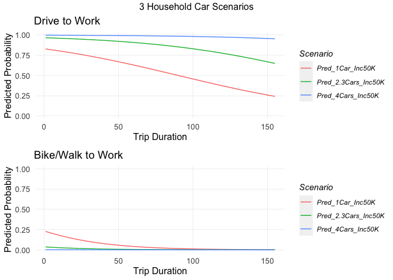

```r
mod <- glm ( drove_work ~ TOTVEH+TRPDUR+INCOME, data=trips_person_hh, family = binomial)
mod2 <- glm ( bike_walk_work ~ TOTVEH+TRPDUR+INCOME, data=trips_person_hh, family = binomial)


#Scenario 1: 1 vs 3 vehicles
newdat_gg<-data.frame(matrix(ncol = 3, nrow = nrow(trips_person_hh)))
colnames(newdat_gg)<- c("TRPDUR", "INCOME", "TOTVEH")
newdat_gg$TRPDUR <- trips_person_hh$TRPDUR
newdat_gg$INCOME <- 50000
newdat_gg$TOTVEH <- mean(trips_person_hh$TOTVEH)

newdat_gg_1<-data.frame(matrix(ncol = 3, nrow = nrow(trips_person_hh)))
colnames(newdat_gg_1)<- c("TRPDUR", "INCOME", "TOTVEH")
newdat_gg_1$TRPDUR <- trips_person_hh$TRPDUR
newdat_gg_1$INCOME <- 50000
newdat_gg_1$TOTVEH <- 1

newdat_gg_2<-data.frame(matrix(ncol = 3, nrow = nrow(trips_person_hh)))
colnames(newdat_gg_2)<- c("TRPDUR", "INCOME", "TOTVEH")
newdat_gg_2$TRPDUR <- trips_person_hh$TRPDUR
newdat_gg_2$INCOME <- 50000
newdat_gg_2$TOTVEH <- 4

#drove
pred_dat<- data.frame(matrix(ncol = 4, nrow = nrow(trips_person_hh)))
colnames(pred_dat)<- c("TRPDUR", "Pred_2.3Cars_Inc50K", "Pred_1Car_Inc50K", "Pred_4Cars_Inc50K")
pred_dat$TRPDUR<-trips_person_hh$TRPDUR
pred_dat$Pred_2.3Cars_Inc50K<- predict(mod, newdat_gg, type="response")
pred_dat$Pred_1Car_Inc50K<- predict(mod, newdat_gg_1, type="response")
pred_dat$Pred_4Cars_Inc50K<- predict(mod, newdat_gg_2, type="response")
#bike/walk
pred_dat2<- data.frame(matrix(ncol = 4, nrow = nrow(trips_person_hh)))
colnames(pred_dat2)<- c("TRPDUR", "Pred_2.3Cars_Inc50K", "Pred_1Car_Inc50K", "Pred_4Cars_Inc50K")
pred_dat2$TRPDUR<-trips_person_hh$TRPDUR
pred_dat2$Pred_2.3Cars_Inc50K<- predict(mod2, newdat_gg, type="response")
pred_dat2$Pred_1Car_Inc50K<- predict(mod2, newdat_gg_1, type="response")
pred_dat2$Pred_4Cars_Inc50K<- predict(mod2, newdat_gg_2, type="response")

dat <- gather(pred_dat, -TRPDUR, key = "Scenario", value = "value")
dat2 <- gather(pred_dat2, -TRPDUR, key = "Scenario", value = "value")

grid.arrange(
ggplot(dat, aes(x = TRPDUR, y = value, colour = Scenario)) +
        geom_line() + ylim(0,1) +
  labs(title = "Drive to Work") +
        xlab("Trip Duration") + ylab("Predicted Probability") +
  plotTheme(),
ggplot(dat2, aes(x = TRPDUR, y = value, colour = Scenario)) +
        geom_line() + ylim(0,1) +
  labs(title = "Bike/Walk to Work") +
        xlab("Trip Duration") + ylab("Predicted Probability")+
plotTheme(), ncol = 1, top = "3 Household Car Scenarios")
```

2. More workers in a household means a person is less likely to drive, and more likely to bike or walk to work. This supports the theory that mode choice is determined, in part, with whether one has to compete with household members for transportation resources.
3. Trip duration is a predictor for mode because on average, a car commute takes 4 minutes longer than a bike or walking commute. It’s possible that this is because people are unlikely to choose biking or walking, more labor intensive modes, for longer commutes.
4. The older someone is, the more likely they are to drive instead of walk or bike. This is expected, as the literature has documented that older populations in the United States tend to prefer automobile transport over other modes. As we see below, when controlling for trip duration and income, older commuters are more likely to drive and less likely to walk or bike compared to younger ones.

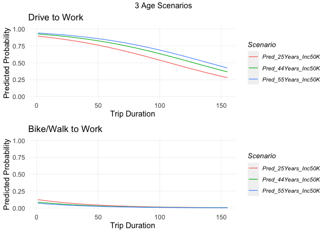

```r
mod <- glm ( drove_work ~ AGE+TRPDUR+INCOME, data=trips_person_hh, family = binomial)
mod2 <- glm ( bike_walk_work ~ AGE+TRPDUR+INCOME, data=trips_person_hh, family = binomial)

#Scenario 2: 20 vs 55 years of age
newdat_gg<-data.frame(matrix(ncol = 3, nrow = nrow(trips_person_hh)))
colnames(newdat_gg)<- c("TRPDUR", "INCOME", "AGE")
newdat_gg$TRPDUR <- trips_person_hh$TRPDUR
newdat_gg$INCOME <- 50000
newdat_gg$AGE <- mean(trips_person_hh$AGE)

newdat_gg_1<-data.frame(matrix(ncol = 3, nrow = nrow(trips_person_hh)))
colnames(newdat_gg_1)<- c("TRPDUR", "INCOME", "AGE")
newdat_gg_1$TRPDUR <- trips_person_hh$TRPDUR
newdat_gg_1$INCOME <- 50000
newdat_gg_1$AGE <- 25

newdat_gg_2<-data.frame(matrix(ncol = 3, nrow = nrow(trips_person_hh)))
colnames(newdat_gg_2)<- c("TRPDUR", "INCOME", "AGE")
newdat_gg_2$TRPDUR <- trips_person_hh$TRPDUR
newdat_gg_2$INCOME <- 50000
newdat_gg_2$AGE <- 55

#drove
pred_dat<- data.frame(matrix(ncol = 4, nrow = nrow(trips_person_hh)))
colnames(pred_dat)<- c("TRPDUR", "Pred_44Years_Inc50K", "Pred_25Years_Inc50K", "Pred_55Years_Inc50K")
pred_dat$TRPDUR<-trips_person_hh$TRPDUR
pred_dat$Pred_44Years_Inc50K<- predict(mod, newdat_gg, type="response")
pred_dat$Pred_25Years_Inc50K<- predict(mod, newdat_gg_1, type="response")
pred_dat$Pred_55Years_Inc50K<- predict(mod, newdat_gg_2, type="response")

pred_dat2<- data.frame(matrix(ncol = 4, nrow = nrow(trips_person_hh)))
colnames(pred_dat2)<- c("TRPDUR", "Pred_44Years_Inc50K", "Pred_25Years_Inc50K", "Pred_55Years_Inc50K")
pred_dat2$TRPDUR<-trips_person_hh$TRPDUR
pred_dat2$Pred_44Years_Inc50K<- predict(mod2, newdat_gg, type="response")
pred_dat2$Pred_25Years_Inc50K<- predict(mod2, newdat_gg_1, type="response")
pred_dat2$Pred_55Years_Inc50K<- predict(mod2, newdat_gg_2, type="response")

dat <- gather(pred_dat, -TRPDUR, key = "Scenario", value = "value")
dat2 <- gather(pred_dat2, -TRPDUR, key = "Scenario", value = "value")

grid.arrange(
ggplot(dat, aes(x = TRPDUR, y = value, colour = Scenario)) +
        geom_line() + ylim(0,1) +
  labs(title = "Drive to Work") +
        xlab("Trip Duration") + ylab("Predicted Probability") + plotTheme() ,
ggplot(dat2, aes(x = TRPDUR, y = value, colour = Scenario)) +
        geom_line() + ylim(0,1) +
  labs(title = "Bike/Walk to Work") +
        xlab("Trip Duration") + ylab("Predicted Probability") + plotTheme(), ncol = 1, top = "3 Age Scenarios")
```

## 2.3 Multinomial Logit: drive, carpool, transit, walk, or bike to work

Now we create a model to predict whether somebody will drive, carpool, ride transit, walk, or bike to work. First, we clean the data and calculate important metrics such as travel time, travel distance, and parking and toll costs for each mode. Driving is the most popular mode by far, with more than 2500 observations. Transit and walking each have less than 200 observations, while biking and carpool each have less than 50.

```r
trips_person_hh <- trips_person_hh %>%
  mutate(walk_work = case_when (TRAN1 == 11  ~ 1, TRUE ~ 0),
         bike_work = case_when(TRAN1 == 14 ~ 1, TRUE ~ 0))

CommuteTripsClean <- trips_person_hh[which(trips$Dest_PTYE == 2), ]

#combine modes into a single column so that we can plot
CommuteTripsClean$Commute[CommuteTripsClean$drove_work == 1] <- 1
CommuteTripsClean$Commute[CommuteTripsClean$carpool_work == 1] <- 2
CommuteTripsClean$Commute[CommuteTripsClean$transit_work == 1] <- 3
CommuteTripsClean$Commute[CommuteTripsClean$walk_work == 1] <- 4
CommuteTripsClean$Commute[CommuteTripsClean$bike_work == 1] <- 5

#are there NAs?
table(is.na(CommuteTripsClean$Commute))
```

```
##
## FALSE  TRUE
##  2919   457
```

```r
table(CommuteTripsClean$Commute)
```

```
##
##    1    2    3    4    5
## 2616   11  144  131   17
```

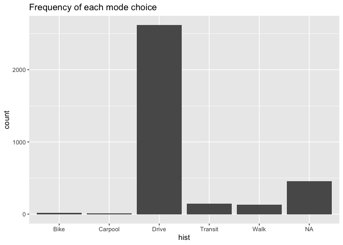

```r
CommuteTripsClean$hist[CommuteTripsClean$Commute == 1] <- "Drive"
CommuteTripsClean$hist[CommuteTripsClean$Commute == 2] <- "Carpool"
CommuteTripsClean$hist[CommuteTripsClean$Commute == 3] <- "Transit"
CommuteTripsClean$hist[CommuteTripsClean$Commute == 4] <- "Walk"
CommuteTripsClean$hist[CommuteTripsClean$Commute == 5] <- "Bike"
CommuteTripsClean$hist <- as.factor(CommuteTripsClean$hist)
#plot frequency of each mode chosen
ggplot(CommuteTripsClean, aes(x=hist)) +
  labs(title = "Frequency of each mode choice") +
  geom_bar()
```

```r
CommuteTripsClean <- subset(CommuteTripsClean, !duplicated(X))

CommuteTripsClean <-CommuteTripsClean %>% filter(!is.na(SAMPN_PER))

#Check for repetition
##Commute_mode <- CommuteTripsClean%>% select(transit_work, drove_work, bike_work, walk_work,carpool_work)
##Commute_mode$check<-
##Commute_mode$transit_work+Commute_mode$drove_work+Commute_mode$bike_work + Commute_mode$walk_work + Commute_mode$carpool_work
##max(Commute_mode$check)

Biking<-CommuteTripsClean[which(CommuteTripsClean$bike_work ==1),]
Walking<-CommuteTripsClean[which(CommuteTripsClean$walk_work ==1),]
Drive<-CommuteTripsClean[which(CommuteTripsClean$drove_work ==1),]
Transit<-CommuteTripsClean[which(CommuteTripsClean$transit_work ==1),]
Carpool <- CommuteTripsClean[which(CommuteTripsClean$carpool_work ==1),]

Drive$distance<-(30/60)*Drive$TRPDUR
Biking$distance<-(12/60)*Biking$TRPDUR
Walking$distance<-(4/60)*Walking$TRPDUR
Transit$distance<-(25/60)*Transit$TRPDUR
Carpool$distance<-(30/60)*Carpool$TRPDUR

dat<-rbind(Biking, Walking, Transit, Carpool, Drive)

dat$time.drove <-dat$distance/30
dat$time.bike <- dat$distance/12
dat$time.transit <- dat$distance/25
dat$time.carpool <- dat$distance/30
dat$time.walk <- dat$distance/4

dat$mode[dat$bike_work == 1] <- "bike"
dat$mode[dat$transit_work == 1] <- "transit"
dat$mode[dat$walk_work == 1] <- "walk"
dat$mode[dat$drove_work == 1] <- "drove"
dat$mode[dat$carpool_work == 1] <- "carpool"

dat2 <- dat %>%
  mutate(with_toll = case_when(TOLLA > 0 ~ 1, TRUE ~ 2),
         with_park = case_when(PARKC > 0 ~ 1, TRUE ~ 2))


rownames(dat2) <- NULL
```

Let’s clean the data further to prepare for modelling.

```r
dat_final <-
  dat2 %>%
  dplyr::select("SAMPN.x", "PERNO.x", "X", "AGE", "INCOME", "SAMPN_PER", "with_toll", "TOLL", "with_park", "PARKU","PARKO" ,"TRPDUR", "drove_work", "transit_work","carpool_work", "GEND", "DISAB", "EDUC", "TOTVEH", "ADVLT", "RENT", "ENGL" , "HHSIZE", "NPHON" , "NOWRK", starts_with("time"),mode)

dat_final[is.na(dat_final)] <- 0

head(dat_final)
```

```
##   SAMPN.x PERNO.x        X AGE INCOME SAMPN_PER with_toll TOLL with_park PARKU
## 1 1009329       3 10093293  16  87000  10093293         2    0         2     0
## 2 1015320       1 10153201  43  87000  10153201         2    0         2     0
## 3 1017282       3 10172823  16  62000  10172823         2    0         2     0
## 4 1027735       3 10277353  17  87000  10277353         2    0         2     0
## 5 1030554       1 10305541  48 137000  10305541         2    0         2     0
## 6 1038864       2 10388642  57 112000  10388642         2    0         2     0
##   PARKO TRPDUR drove_work transit_work carpool_work GEND DISAB EDUC TOTVEH
## 1            4          0            0            0    1     2    1      2
## 2           60          0            0            0    1     2    1      1
## 3            1          0            0            0    1     2    1      3
## 4           60          0            0            0    2     2    1      1
## 5           50          0            0            0    1     2    2      2
## 6           11          0            0            0    1     2    2      1
##   ADVLT RENT ENGL HHSIZE NPHON NOWRK  time.drove  time.bike time.transit
## 1     8    2    2      8     1     2 0.026666667 0.06666667        0.032
## 2     3    2    2      5     1     2 0.400000000 1.00000000        0.480
## 3     3    2    2      4     1     3 0.006666667 0.01666667        0.008
## 4     2    2    2      6     1     3 0.400000000 1.00000000        0.480
## 5     3    2    2      4     2     2 0.333333333 0.83333333        0.400
## 6     1    2    2      2     1     2 0.073333333 0.18333333        0.088
##   time.carpool time.walk mode
## 1  0.026666667      0.20 bike
## 2  0.400000000      3.00 bike
## 3  0.006666667      0.05 bike
## 4  0.400000000      3.00 bike
## 5  0.333333333      2.50 bike
## 6  0.073333333      0.55 bike
```

```r
library(mlogit)
datMNL <- mlogit.data(dat_final, shape="wide", choice="mode", varying=c(26:30))

head(datMNL)
```

```
## ~~~~~~~
##  first 10 observations out of 14595
## ~~~~~~~
##    SAMPN.x PERNO.x        X AGE INCOME SAMPN_PER with_toll TOLL with_park PARKU
## 1  1009329       3 10093293  16  87000  10093293         2    0         2     0
## 2  1009329       3 10093293  16  87000  10093293         2    0         2     0
## 3  1009329       3 10093293  16  87000  10093293         2    0         2     0
## 4  1009329       3 10093293  16  87000  10093293         2    0         2     0
## 5  1009329       3 10093293  16  87000  10093293         2    0         2     0
## 6  1015320       1 10153201  43  87000  10153201         2    0         2     0
## 7  1015320       1 10153201  43  87000  10153201         2    0         2     0
## 8  1015320       1 10153201  43  87000  10153201         2    0         2     0
## 9  1015320       1 10153201  43  87000  10153201         2    0         2     0
## 10 1015320       1 10153201  43  87000  10153201         2    0         2     0
##    PARKO TRPDUR drove_work transit_work carpool_work GEND DISAB EDUC TOTVEH
```

[output cut: 35 more lines]

We selected variables that are relevant across all modes (i.e. toll or parking are only related to driving, so we excluded them). Below, we create 3 models to start: a model with only decision maker specific variables, a model with alternative and decision maker specific variables, and a model with only alternative specific variables. The model with both alternative and decision maker variables has the highest McFadden R^2.

```r
#mod 1
mod1 <- mlogit (mode ~ 1 | AGE + INCOME +GEND + EDUC + TOTVEH + RENT + ADVLT + NPHON +NOWRK + HHSIZE, data = datMNL)
summary(mod1)
```

```
##
## Call:
## mlogit(formula = mode ~ 1 | AGE + INCOME + GEND + EDUC + TOTVEH +
##     RENT + ADVLT + NPHON + NOWRK + HHSIZE, data = datMNL, method = "nr")
##
## Frequencies of alternatives:choice
##      bike   carpool     drove   transit      walk
## 0.0058239 0.0037684 0.8961973 0.0493320 0.0448784
##
## nr method
## 8 iterations, 0h:0m:1s
## g'(-H)^-1g = 8.01E-07
## gradient close to zero
##
## Coefficients :
##                        Estimate  Std. Error z-value  Pr(>|z|)
## (Intercept):carpool -1.1798e+01  3.5698e+00 -3.3049 0.0009502 ***
## (Intercept):drove   -5.8788e+00  2.0292e+00 -2.8971 0.0037666 **
## (Intercept):transit -5.2988e+00  2.0975e+00 -2.5263 0.0115281 *
## (Intercept):walk    -5.6626e+00  2.1159e+00 -2.6762 0.0074462 **
## AGE:carpool          3.6599e-02  3.8211e-02  0.9578 0.3381597
## AGE:drove            3.1804e-02  2.6654e-02  1.1932 0.2327927
## AGE:transit          1.5867e-02  2.7516e-02  0.5766 0.5641771
## AGE:walk             1.6701e-02  2.7544e-02  0.6063 0.5442875
## INCOME:carpool      -3.9672e-05  1.2580e-05 -3.1536 0.0016126 **
## INCOME:drove        -2.5161e-05  6.7305e-06 -3.7384 0.0001852 ***
## INCOME:transit      -3.1979e-05  7.3548e-06 -4.3480 1.374e-05 ***
## INCOME:walk         -1.6328e-05  6.9607e-06 -2.3458 0.0189869 *
## GEND:carpool         1.9487e+00  8.8750e-01  2.1958 0.0281093 *
## GEND:drove           1.3414e+00  6.2283e-01  2.1537 0.0312674 *
## GEND:transit         1.6115e+00  6.3890e-01  2.5222 0.0116610 *
## GEND:walk            1.5001e+00  6.3882e-01  2.3482 0.0188664 *
## EDUC:carpool         2.1704e+00  1.2794e+00  1.6965 0.0897997 .
## EDUC:drove           2.3426e+00  6.4389e-01  3.6383 0.0002745 ***
## EDUC:transit         1.8010e+00  6.8119e-01  2.6439 0.0081954 **
## EDUC:walk            2.0309e+00  6.9571e-01  2.9192 0.0035089 **
## TOTVEH:carpool       2.6006e+00  5.7009e-01  4.5617 5.073e-06 ***
## TOTVEH:drove         2.7787e+00  4.1573e-01  6.6840 2.326e-11 ***
## TOTVEH:transit       1.0665e+00  4.2483e-01  2.5104 0.0120582 *
## TOTVEH:walk          8.0928e-01  4.2198e-01  1.9178 0.0551328 .
```

[output cut: 11 more lines]

```
## NPHON:walk           1.8208e+00  1.0721e+00  1.6984 0.0894396 .
## NOWRK:carpool       -3.2219e-01  6.6594e-01 -0.4838 0.6285157
## NOWRK:drove         -5.6472e-01  4.7405e-01 -1.1913 0.2335518
## NOWRK:transit       -4.4361e-03  4.8998e-01 -0.0091 0.9927763
## NOWRK:walk           5.6002e-01  4.9286e-01  1.1363 0.2558419
## HHSIZE:carpool      -9.1118e-02  3.0549e-01 -0.2983 0.7655002
## HHSIZE:drove        -2.7972e-01  1.8522e-01 -1.5102 0.1309809
## HHSIZE:transit      -1.0887e-01  1.9216e-01 -0.5665 0.5710243
## HHSIZE:walk         -3.6530e-01  1.9860e-01 -1.8393 0.0658690 .
## ---
## Signif. codes:  0 '***' 0.001 '**' 0.01 '*' 0.05 '.' 0.1 ' ' 1
##
## Log-Likelihood: -1011.4
## McFadden R^2:  0.20707
## Likelihood ratio test : chisq = 528.24 (p.value = < 2.22e-16)
```

```r
#mod 2 with time
mod2 <-mlogit (mode ~ time | AGE + INCOME +GEND + EDUC + TOTVEH + RENT + ADVLT + NPHON +NOWRK + HHSIZE, data = datMNL)
summary(mod2)
```

```
##
## Call:
## mlogit(formula = mode ~ time | AGE + INCOME + GEND + EDUC + TOTVEH +
##     RENT + ADVLT + NPHON + NOWRK + HHSIZE, data = datMNL, method = "nr")
##
## Frequencies of alternatives:choice
##      bike   carpool     drove   transit      walk
## 0.0058239 0.0037684 0.8961973 0.0493320 0.0448784
##
## nr method
## 10 iterations, 0h:0m:1s
## g'(-H)^-1g = 1.3E-06
## successive function values within tolerance limits
##
## Coefficients :
##                        Estimate  Std. Error  z-value  Pr(>|z|)
## (Intercept):carpool -1.4554e+01  3.6232e+00  -4.0169 5.897e-05 ***
## (Intercept):drove   -8.6059e+00  2.1400e+00  -4.0215 5.782e-05 ***
## (Intercept):transit -7.4855e+00  2.2126e+00  -3.3831 0.0007168 ***
## (Intercept):walk    -3.4010e+00  2.1837e+00  -1.5575 0.1193516
## time                -4.5444e+00  4.0246e-01 -11.2918 < 2.2e-16 ***
## AGE:carpool          3.7832e-02  3.8776e-02   0.9757 0.3292371
## AGE:drove            3.3210e-02  2.7432e-02   1.2107 0.2260262
## AGE:transit          1.3813e-02  2.8326e-02   0.4877 0.6257961
## AGE:walk             1.6436e-02  2.8698e-02   0.5727 0.5668391
## INCOME:carpool      -3.9146e-05  1.2756e-05  -3.0689 0.0021483 **
## INCOME:drove        -2.4562e-05  7.0044e-06  -3.5067 0.0004537 ***
## INCOME:transit      -3.0162e-05  7.5986e-06  -3.9695 7.204e-05 ***
## INCOME:walk         -1.5987e-05  7.1370e-06  -2.2400 0.0250915 *
## GEND:carpool         2.1394e+00  9.0462e-01   2.3650 0.0180293 *
## GEND:drove           1.5319e+00  6.4726e-01   2.3667 0.0179472 *
## GEND:transit         1.7481e+00  6.6288e-01   2.6371 0.0083626 **
## GEND:walk            1.5140e+00  6.7128e-01   2.2553 0.0241137 *
## EDUC:carpool         2.2542e+00  1.3029e+00   1.7301 0.0836153 .
## EDUC:drove           2.4047e+00  6.9965e-01   3.4371 0.0005881 ***
## EDUC:transit         1.9790e+00  7.3803e-01   2.6815 0.0073294 **
## EDUC:walk            1.8607e+00  7.6956e-01   2.4179 0.0156118 *
## TOTVEH:carpool       2.9275e+00  5.9647e-01   4.9080 9.201e-07 ***
## TOTVEH:drove         3.0980e+00  4.5543e-01   6.8024 1.029e-11 ***
## TOTVEH:transit       1.3267e+00  4.6239e-01   2.8692 0.0041157 **
```

[output cut: 12 more lines]

```
## NPHON:walk           1.6365e+00  1.0859e+00   1.5070 0.1318086
## NOWRK:carpool       -3.7238e-01  6.8668e-01  -0.5423 0.5876189
## NOWRK:drove         -6.0984e-01  5.0509e-01  -1.2074 0.2272838
## NOWRK:transit       -1.1311e-01  5.2007e-01  -0.2175 0.8278228
## NOWRK:walk           6.2782e-01  5.3256e-01   1.1789 0.2384448
## HHSIZE:carpool      -5.2914e-02  3.0284e-01  -0.1747 0.8612966
## HHSIZE:drove        -2.3639e-01  1.8102e-01  -1.3058 0.1916109
## HHSIZE:transit      -7.9270e-02  1.8681e-01  -0.4243 0.6713243
## HHSIZE:walk         -3.3339e-01  2.0101e-01  -1.6586 0.0971970 .
## ---
## Signif. codes:  0 '***' 0.001 '**' 0.01 '*' 0.05 '.' 0.1 ' ' 1
##
## Log-Likelihood: -754.41
## McFadden R^2:  0.40853
## Likelihood ratio test : chisq = 1042.2 (p.value = < 2.22e-16)
```

```r
#mod 3 only with time
mod3 <-mlogit (mode ~ time | 1, data = datMNL)
summary(mod3)
```

```
##
## Call:
## mlogit(formula = mode ~ time | 1, data = datMNL, method = "nr")
##
## Frequencies of alternatives:choice
##      bike   carpool     drove   transit      walk
## 0.0058239 0.0037684 0.8961973 0.0493320 0.0448784
##
## nr method
## 9 iterations, 0h:0m:0s
## g'(-H)^-1g = 0.000164
## successive function values within tolerance limits
##
## Coefficients :
##                     Estimate Std. Error  z-value  Pr(>|z|)
## (Intercept):carpool -2.30051    0.40039  -5.7457 9.154e-09 ***
## (Intercept):drove    3.17100    0.26417  12.0038 < 2.2e-16 ***
## (Intercept):transit  0.63920    0.26753   2.3893   0.01688 *
## (Intercept):walk     4.22558    0.27016  15.6410 < 2.2e-16 ***
## time                -4.46191    0.34687 -12.8632 < 2.2e-16 ***
## ---
## Signif. codes:  0 '***' 0.001 '**' 0.01 '*' 0.05 '.' 0.1 ' ' 1
##
## Log-Likelihood: -985.13
## McFadden R^2:  0.22764
## Likelihood ratio test : chisq = 580.71 (p.value = < 2.22e-16)
```

Based on this, we create a more succinct model based on model 2, removing statistically insignificant variables. The list of variables we use includes: INCOME, GEND, EDUC, TOTVEH, NPHON, and HHSIZE. This reduction in variables slightly lowers the model’s McFadden R^2, but it now has a much higher proportion of significant variables. The AIC varies very little between model 2 and model 4 as well.

```r
#mod 4: with time and decisionmaker specific, insignificant variables removed
mod4 <-mlogit (mode ~ time | INCOME + GEND + EDUC + TOTVEH + NPHON + HHSIZE, data = datMNL)
summary(mod4)
```

```
##
## Call:
## mlogit(formula = mode ~ time | INCOME + GEND + EDUC + TOTVEH +
##     NPHON + HHSIZE, data = datMNL, method = "nr")
##
## Frequencies of alternatives:choice
##      bike   carpool     drove   transit      walk
## 0.0058239 0.0037684 0.8961973 0.0493320 0.0448784
##
## nr method
## 9 iterations, 0h:0m:1s
## g'(-H)^-1g = 0.000889
## successive function values within tolerance limits
##
## Coefficients :
##                        Estimate  Std. Error  z-value  Pr(>|z|)
## (Intercept):carpool -1.4271e+01  3.1925e+00  -4.4702 7.815e-06 ***
## (Intercept):drove   -8.4027e+00  1.8398e+00  -4.5672 4.942e-06 ***
## (Intercept):transit -7.7999e+00  1.9141e+00  -4.0750 4.602e-05 ***
## (Intercept):walk    -2.9319e+00  1.8838e+00  -1.5564 0.1196142
## time                -4.6018e+00  3.9861e-01 -11.5446 < 2.2e-16 ***
## INCOME:carpool      -3.7641e-05  1.2411e-05  -3.0329 0.0024222 **
## INCOME:drove        -2.3303e-05  6.6019e-06  -3.5298 0.0004159 ***
## INCOME:transit      -2.9410e-05  7.2032e-06  -4.0830 4.446e-05 ***
## INCOME:walk         -1.4919e-05  6.7679e-06  -2.2045 0.0274921 *
## GEND:carpool         2.1593e+00  8.9614e-01   2.4096 0.0159718 *
## GEND:drove           1.5181e+00  6.3793e-01   2.3798 0.0173226 *
## GEND:transit         1.7317e+00  6.5425e-01   2.6469 0.0081244 **
## GEND:walk            1.5615e+00  6.5952e-01   2.3676 0.0179048 *
## EDUC:carpool         2.7806e+00  1.2052e+00   2.3071 0.0210486 *
## EDUC:drove           2.9604e+00  6.1872e-01   4.7848 1.712e-06 ***
## EDUC:transit         2.2030e+00  6.5791e-01   3.3485 0.0008126 ***
## EDUC:walk            1.9205e+00  6.7902e-01   2.8283 0.0046797 **
## TOTVEH:carpool       2.7390e+00  5.4397e-01   5.0352 4.774e-07 ***
## TOTVEH:drove         2.8518e+00  4.2337e-01   6.7361 1.626e-11 ***
## TOTVEH:transit       1.1663e+00  4.3069e-01   2.7080 0.0067695 **
## TOTVEH:walk          1.1614e+00  4.3067e-01   2.6967 0.0070035 **
## NPHON:carpool        2.1634e+00  1.1511e+00   1.8794 0.0601861 .
## NPHON:drove          1.9941e+00  1.0726e+00   1.8591 0.0630119 .
## NPHON:transit        2.3862e+00  1.0790e+00   2.2116 0.0269964 *
## NPHON:walk           1.7034e+00  1.0859e+00   1.5687 0.1167251
## HHSIZE:carpool      -2.0732e-01  2.5820e-01  -0.8030 0.4220003
## HHSIZE:drove        -4.3716e-01  1.5083e-01  -2.8985 0.0037497 **
## HHSIZE:transit      -1.4064e-01  1.5371e-01  -0.9149 0.3602195
## HHSIZE:walk         -2.6025e-01  1.6488e-01  -1.5784 0.1144669
## ---
## Signif. codes:  0 '***' 0.001 '**' 0.01 '*' 0.05 '.' 0.1 ' ' 1
##
## Log-Likelihood: -780.35
## McFadden R^2:  0.3882
## Likelihood ratio test : chisq = 990.28 (p.value = < 2.22e-16)
```

```r
AIC(mod1, mod2, mod3, mod4)
```

```
##      df      AIC
## mod1 44 2110.743
## mod2 45 1598.820
## mod3  5 1980.270
## mod4 29 1618.700
```

```r
#think back to chisq test we did for binomial
modelChi <- (-2*(-780.35)) - (-2*(-754.41))
#-754.4 = log likelihood for mod2
#-780.35 = log likelihood for mod4
#this is the chisq in output

#calculating change in degree of freedom
mod4$logLik
```

```
## 'log Lik.' -780.3502 (df=29)
```

```r
df.mod4 <- 29
mod2$logLik
```

```
## 'log Lik.' -754.41 (df=45)
```

```r
df.mod2 <- 45

chidf <- df.mod4 - df.mod2

#if prob < 0.05, then the final model significantly improves fit
chisq.prob <- 1 - pchisq(modelChi, chidf)
chisq.prob #this is the chisq p-value in the output
```

```
## [1] NaN
```

The results below show the possibilities of choosing any of the 5 modes predicted by our model 4.

For example, given all the circumstance in observation 1, the possibility of anyone choosing this mode of transportation is 32%.

```r
summary(mod4)
```

```
##
## Call:
## mlogit(formula = mode ~ time | INCOME + GEND + EDUC + TOTVEH +
##     NPHON + HHSIZE, data = datMNL, method = "nr")
##
## Frequencies of alternatives:choice
##      bike   carpool     drove   transit      walk
## 0.0058239 0.0037684 0.8961973 0.0493320 0.0448784
##
## nr method
## 9 iterations, 0h:0m:1s
## g'(-H)^-1g = 0.000889
## successive function values within tolerance limits
##
## Coefficients :
##                        Estimate  Std. Error  z-value  Pr(>|z|)
## (Intercept):carpool -1.4271e+01  3.1925e+00  -4.4702 7.815e-06 ***
## (Intercept):drove   -8.4027e+00  1.8398e+00  -4.5672 4.942e-06 ***
## (Intercept):transit -7.7999e+00  1.9141e+00  -4.0750 4.602e-05 ***
## (Intercept):walk    -2.9319e+00  1.8838e+00  -1.5564 0.1196142
## time                -4.6018e+00  3.9861e-01 -11.5446 < 2.2e-16 ***
## INCOME:carpool      -3.7641e-05  1.2411e-05  -3.0329 0.0024222 **
## INCOME:drove        -2.3303e-05  6.6019e-06  -3.5298 0.0004159 ***
## INCOME:transit      -2.9410e-05  7.2032e-06  -4.0830 4.446e-05 ***
## INCOME:walk         -1.4919e-05  6.7679e-06  -2.2045 0.0274921 *
## GEND:carpool         2.1593e+00  8.9614e-01   2.4096 0.0159718 *
## GEND:drove           1.5181e+00  6.3793e-01   2.3798 0.0173226 *
## GEND:transit         1.7317e+00  6.5425e-01   2.6469 0.0081244 **
## GEND:walk            1.5615e+00  6.5952e-01   2.3676 0.0179048 *
## EDUC:carpool         2.7806e+00  1.2052e+00   2.3071 0.0210486 *
## EDUC:drove           2.9604e+00  6.1872e-01   4.7848 1.712e-06 ***
## EDUC:transit         2.2030e+00  6.5791e-01   3.3485 0.0008126 ***
## EDUC:walk            1.9205e+00  6.7902e-01   2.8283 0.0046797 **
## TOTVEH:carpool       2.7390e+00  5.4397e-01   5.0352 4.774e-07 ***
## TOTVEH:drove         2.8518e+00  4.2337e-01   6.7361 1.626e-11 ***
## TOTVEH:transit       1.1663e+00  4.3069e-01   2.7080 0.0067695 **
## TOTVEH:walk          1.1614e+00  4.3067e-01   2.6967 0.0070035 **
## NPHON:carpool        2.1634e+00  1.1511e+00   1.8794 0.0601861 .
## NPHON:drove          1.9941e+00  1.0726e+00   1.8591 0.0630119 .
## NPHON:transit        2.3862e+00  1.0790e+00   2.2116 0.0269964 *
## NPHON:walk           1.7034e+00  1.0859e+00   1.5687 0.1167251
## HHSIZE:carpool      -2.0732e-01  2.5820e-01  -0.8030 0.4220003
## HHSIZE:drove        -4.3716e-01  1.5083e-01  -2.8985 0.0037497 **
## HHSIZE:transit      -1.4064e-01  1.5371e-01  -0.9149 0.3602195
## HHSIZE:walk         -2.6025e-01  1.6488e-01  -1.5784 0.1144669
## ---
## Signif. codes:  0 '***' 0.001 '**' 0.01 '*' 0.05 '.' 0.1 ' ' 1
##
## Log-Likelihood: -780.35
## McFadden R^2:  0.3882
## Likelihood ratio test : chisq = 990.28 (p.value = < 2.22e-16)
```

```r
fitted(mod4, outcome = TRUE, 30)   #probability of choosing any of the 4 modes
```

```
##            1            2            3            4            5            6
## 3.257090e-01 5.268825e-01 1.398276e-02 2.347989e-01 2.176452e-03 1.242007e-01
##            7            8            9           10           11           12
## 1.286189e-01 6.377274e-01 1.042962e-01 1.215569e-02 1.543661e-01 2.116141e-02
##           13           14           15           16           17           18
## 7.872674e-01 8.256648e-03 9.612379e-02 1.859144e-01 5.761984e-02 5.916523e-02
##           19           20           21           22           23           24
## 7.960773e-01 3.023068e-01 5.466525e-02 6.242166e-02 4.898095e-01 7.905499e-01
##           25           26           27           28           29           30
## 8.382914e-01 5.556759e-01 2.390233e-01 8.651809e-01 1.704179e-01 7.377515e-01
##           31           32           33           34           35           36
## 8.882704e-01 6.592869e-01 4.337190e-02 6.926599e-01 3.716230e-01 5.419654e-01
##           37           38           39           40           41           42
## 7.263605e-01 6.589043e-01 7.600836e-01 9.625791e-02 6.536889e-01 9.146065e-01
##           43           44           45           46           47           48
## 8.509411e-01 2.883162e-01 1.789491e-01 7.804829e-02 2.845712e-01 2.845712e-01
##           49           50           51           52           53           54
## 7.673560e-01 9.223852e-01 2.611159e-01 4.999317e-01 5.827217e-01 5.013421e-01
##           55           56           57           58           59           60
## 8.315921e-01 4.167596e-01 4.247527e-01 3.654049e-01 5.462119e-01 1.239392e-01
##           61           62           63           64           65           66
## 8.163283e-01 6.203852e-01 7.912750e-01 5.957342e-01 8.995546e-01 8.895458e-01
##           67           68           69           70           71           72
## 8.634008e-01 7.771870e-01 8.768087e-01 7.392699e-01 7.392699e-01 8.279689e-01
##           73           74           75           76           77           78
## 8.867839e-01 6.613811e-01 8.122970e-01 3.362552e-02 6.172720e-01 6.172720e-01
##           79           80           81           82           83           84
## 6.493060e-01 6.835312e-01 6.910284e-01 6.562426e-01 9.077663e-01 7.201531e-01
##           85           86           87           88           89           90
## 8.685409e-01 6.671636e-02 2.794650e-01 8.694763e-01 8.694763e-01 7.731747e-01
##           91           92           93           94           95           96
## 2.805221e-01 6.121035e-02 1.779224e-03 4.932210e-01 4.871188e-01 5.271791e-01
##           97           98           99          100          101          102
## 1.045590e-01 5.332672e-01 1.823039e-01 4.795378e-02 8.105277e-01 8.497249e-01
##          103          104          105          106          107          108
## 2.342250e-01 2.769337e-01 6.563485e-01 6.841645e-01 8.246672e-01 8.275164e-01
##          109          110          111          112          113          114
## 4.824593e-01 7.417918e-01 1.445611e-01 5.883459e-01 4.962745e-01 4.202438e-01
##          115          116          117          118          119          120
## 2.896497e-01 8.029353e-01 2.460099e-01 6.783889e-01 7.057501e-01 3.305793e-01
```

[output cut: 919 more lines]

```
## 1.473532e-01 7.061432e-01 9.532133e-01 9.741694e-01 8.891709e-01 8.756690e-01
##         2881         2882         2883         2884         2885         2886
## 9.263956e-01 9.660493e-01 9.766583e-01 9.675426e-01 8.311191e-01 5.539667e-01
##         2887         2888         2889         2890         2891         2892
## 2.970729e-01 9.536423e-01 9.694804e-01 9.728851e-01 7.994579e-01 8.808908e-01
##         2893         2894         2895         2896         2897         2898
## 9.657344e-01 9.941595e-01 9.887328e-01 9.975221e-01 9.986912e-01 9.967764e-01
##         2899         2900         2901         2902         2903         2904
## 9.940945e-01 9.941292e-01 9.924977e-01 9.211035e-01 8.731863e-01 9.625834e-01
##         2905         2906         2907         2908         2909         2910
## 9.078819e-01 9.771518e-01 9.949155e-01 9.475450e-01 9.810923e-01 9.810923e-01
##         2911         2912         2913         2914         2915         2916
## 9.881717e-01 7.803510e-01 9.613830e-01 9.471858e-01 8.717860e-01 8.997009e-01
##         2917         2918         2919
## 9.753890e-01 9.485772e-01 9.312671e-01
```

## 2.4 Conclusion

### 2.4.1 Model results

The table below shows the model summary:

```r
library(stargazer)
stargazer(mod2, mod4, type = "text")
```

```
##
## ===============================================================
##                                 Dependent variable:
##                     -------------------------------------------
##                                        mode
##                              (1)                   (2)
## ---------------------------------------------------------------
## (Intercept):carpool       -14.554***            -14.271***
##                            (3.623)               (3.192)
##
## (Intercept):drove         -8.606***             -8.403***
##                            (2.140)               (1.840)
##
## (Intercept):transit       -7.485***             -7.800***
##                            (2.213)               (1.914)
##
## (Intercept):walk            -3.401                -2.932
##                            (2.184)               (1.884)
##
## time                      -4.544***             -4.602***
##                            (0.402)               (0.399)
##
## AGE:carpool                 0.038
##                            (0.039)
##
## AGE:drove                   0.033
##                            (0.027)
##
## AGE:transit                 0.014
##                            (0.028)
##
## AGE:walk                    0.016
##                            (0.029)
##
## INCOME:carpool           -0.00004***           -0.00004***
##                           (0.00001)             (0.00001)
##
## INCOME:drove             -0.00002***           -0.00002***
##                           (0.00001)             (0.00001)
##
```

[output cut: 94 more lines]

```
##                            (0.181)               (0.151)
##
## HHSIZE:transit              -0.079                -0.141
##                            (0.187)               (0.154)
##
## HHSIZE:walk                -0.333*                -0.260
##                            (0.201)               (0.165)
##
## ---------------------------------------------------------------
## Observations                2,919                 2,919
## R2                          0.409                 0.388
## Log Likelihood             -754.410              -780.350
## LR Test             1,042.160*** (df = 45) 990.280*** (df = 29)
## ===============================================================
## Note:                               *p<0.1; **p<0.05; ***p<0.01
```

The model takes mode “biking” as a reference mode. As travel times increases, people are less likely to take transit, drive, carpool, or walk compare to biking.

The change in another variables (given as a coefficients) is associated with the change in odd ratio of the specific mode against the odd ratio of biking while keeping other variables constant.

For example, let’s look at “HHSIZE: transit”. An unit increase in household size is associated with a 13% decrease in the odds of people taking transit compared to biking. This means, people who have larger houses have higher chance of being bikers than transit users.

```r
100 * (exp(coef(mod4))-1)
```

```
## (Intercept):carpool   (Intercept):drove (Intercept):transit    (Intercept):walk
##       -9.999994e+01       -9.997757e+01       -9.995902e+01       -9.467047e+01
##                time      INCOME:carpool        INCOME:drove      INCOME:transit
##       -9.899658e+01       -3.764029e-03       -2.330300e-03       -2.941006e-03
##         INCOME:walk        GEND:carpool          GEND:drove        GEND:transit
##       -1.491933e-03        7.665055e+02        3.563725e+02        4.650259e+02
##           GEND:walk        EDUC:carpool          EDUC:drove        EDUC:transit
##        3.765841e+02        1.512922e+03        1.830635e+03        8.051913e+02
##           EDUC:walk      TOTVEH:carpool        TOTVEH:drove      TOTVEH:transit
##        5.824054e+02        1.447124e+03        1.631979e+03        2.210074e+02
##         TOTVEH:walk       NPHON:carpool         NPHON:drove       NPHON:transit
##        2.194328e+02        7.700416e+02        6.345684e+02        9.872388e+02
##          NPHON:walk      HHSIZE:carpool        HHSIZE:drove      HHSIZE:transit
##        4.492755e+02       -1.872417e+01       -3.541344e+01       -1.311964e+01
##         HHSIZE:walk
##       -2.291427e+01
```

## 2.5 Model performance

According to **Behavioral Travel Modelling**, edited by David Hensher and Peter Stopher in 1979, a R2 between 0.2-0.4 represents an excellent fit. Our model has a great fit with an R2 of 0.39.

Let’s now predict the results based on different time.

```r
str(datMNL)
```

[output not shown]

[output cut: 105 more lines]

[output not shown]

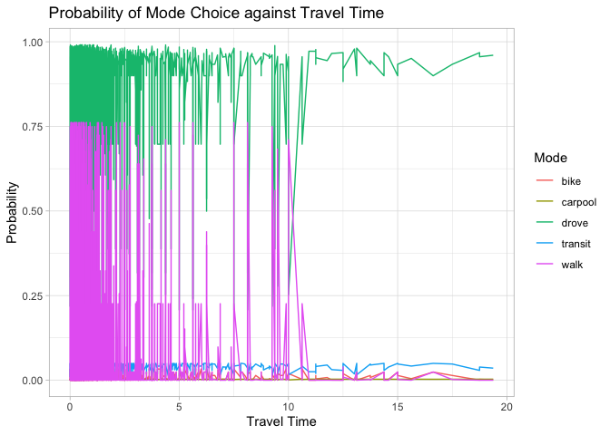

```r
dtime <- data.frame(time = datMNL$time, GEND=1,INCOME=mean(dat$INCOME), EDUC = 1, TOTVEH = mean(datMNL$TOTVEH), NPHON = mean(datMNL$NPHON), HHSIZE = mean(datMNL$HHSIZE))

pp.time <- cbind(dtime, predict(mod4, newdata = dtime, type = "probs", se = TRUE)) %>%
  select(time, drove,bike,walk,transit, carpool)

  pp.time %>%
  gather(Varible, Value, -time) %>%
  ggplot(aes(x = time, y = Value, color = Varible)) + geom_line() +  theme_light() + ylab("Probability") + xlab("Travel Time") + labs(title = "Probability of Mode Choice against Travel Time", color = "Mode")
```

The model performs the worst on walking, because the variation is just so large among the prediction results with a range between 0.00 - 0.75. This makes sense, because we have few observations on walking, which makes the results more inconsistent.

## 2.6 Model limitations

The model could be improved if we incorporated the estimated cost of each trip by different modes. This is a little difficult to calculate, since the transit cost per mile might vary depending on the distance.